# EDA HasClaim Dependant Features R Notebook

In this notebook I investigate what features are dependent with target (hasclaim) in order to exclude from the further analysis independent features.

1. Needed Libraries

```r
# Data visualization
library(funModeling)
```

```r
#mosaic plot
library(vcd)
#alluvial plot
library(alluvial)
#other
library(ggplot2)
#
library(dplyr)
#measure of association
library(vcdExtra)
```

2. Data Load and preprocessing. The data are read as char and should be converted in numerical and factors.

```r
#
dataset <- read.csv('data/fdata_v1_trgencd.csv',stringsAsFactors = FALSE )
#removing spaces
dataset <- data.frame(lapply(dataset, trimws), stringsAsFactors = FALSE)


target <- 'hasclaim'
categorical <- c(
 'external_make',
 'external_model',
 'manufacturer',
 'model',
 'registrationstateprovcd',
 'vehbodytypecd',
 'performancecd',
 'restraintcd',
 'antitheftcd',
 'enginecylinders',
 'vehusecd',
 'classcd',
 'carpoolind',
 'daylightrunninglightsind',
 'passiveseatbeltind',
 'programtypecd',
 'driverstatuscd',
 'licensedstateprovcd',
 'relationshiptoinsuredcd',
 'scholasticdiscountind',
 'mvrstatus',
 'maturedriverind',
 'drivertrainingind',
 'gooddriverind',
 'accidentpreventioncourseind',
 'persontypecd',
 'gendercd',
 'maritalstatuscd',
 'occupationclasscd')

categorical_encd <- c('external_make_encd',
 'external_model_encd',
 'manufacturer_encd',
 'model_encd',
 'registrationstateprovcd_encd',
 'vehbodytypecd_encd',
 'performancecd_encd',
 'restraintcd_encd',
 'antitheftcd_encd',
 'enginecylinders_encd',
 'vehusecd_encd',
 'classcd_encd',
 'carpoolind_encd',
 'daylightrunninglightsind_encd',
 'passiveseatbeltind_encd',
 'programtypecd_encd',
 'driverstatuscd_encd',
 'licensedstateprovcd_encd',
 'relationshiptoinsuredcd_encd',
 'scholasticdiscountind_encd',
 'mvrstatus_encd',
 'maturedriverind_encd',
 'drivertrainingind_encd',
 'gooddriverind_encd',
 'accidentpreventioncourseind_encd',
 'persontypecd_encd',
 'gendercd_encd',
 'maritalstatuscd_encd',
 'occupationclasscd_encd')

categorical_n <- c(
 'garageterritory',
 'vehnumber',
 'drivernumber',
 'viol_pointschargedterm',
 'acci_pointschargedterm',
 'viol_driverpointsnumbercountterm',
 'acci_driverpointsnumbercountterm',
 'viol_infractioncdcountterm',
 'acci_infractioncdcountterm',
 'viol_last_infractionage',
 'acci_last_infractionage',
 'viol_last_convictionage',
 'acci_last_convictionage',
 'external_engine',
 'enginesize',
 'enginehorsepower')

target_binned <- c(
 'external_make_trgbin',
 'external_model_trgbin',
 'manufacturer_trgbin',
 'model_trgbin',
 'registrationstateprovcd_trgbin',
 'vehbodytypecd_trgbin',
 'performancecd_trgbin',
 'restraintcd_trgbin',
 'antitheftcd_trgbin',
 'enginecylinders_trgbin',
 'vehusecd_trgbin',
 'classcd_trgbin',
 'licensedstateprovcd_trgbin',
 'occupationclasscd_trgbin',
 'garageterritory_trgbin',
 'vehnumber_trgbin',
 'drivernumber_trgbin',
 'viol_pointschargedterm_trgbin',
 'acci_pointschargedterm_trgbin',
 'viol_driverpointsnumbercountterm_trgbin',
 'acci_driverpointsnumbercountterm_trgbin',
 'viol_infractioncdcountterm_trgbin',
 'viol_last_infractionage_trgbin',
 'acci_last_infractionage_trgbin',
 'viol_last_convictionage_trgbin',
 'acci_last_convictionage_trgbin',
 'external_engine_trgbin',
 'enginesize_trgbin',
 'enginehorsepower_trgbin')


continuous <- c(  'modelscore',
 'external_length_in',
 'external_width_in',
 'external_height_in',
 'external_vehicleage',
 'vehicleage',
 'ratingvalue',
 'estimatedannualdistance',
 'odometerreading',
 'daysperweekdriven',
 'driverage',
 'havelicenseage',
 'mvrstatusage')



#converting to numerical and factors
dataset[c(target)] <- lapply(dataset[c(target)], factor)
#
dataset[categorical] <- lapply(dataset[categorical], factor)
dataset[categorical_encd] <- lapply(dataset[categorical_encd], factor)
dataset[categorical_n] <- lapply(dataset[categorical_n], factor)
dataset[target_binned] <- lapply(dataset[target_binned], factor)
#
dataset[continuous] <- sapply(dataset[continuous], as.numeric)
```

3. General Information. Output is saved to a csv files to be analyzed later in Excel 3.1 Data Structure

```r
print(str(dataset, list.len=ncol(dataset)))
```

```
## 'data.frame':    132874 obs. of  160 variables:
##  $ X                                      : chr  "0" "1" "2" "3" ...
##  $ Unnamed..0                             : chr  "0" "1" "2" "3" ...
##  $ hasclaim                               : Factor w/ 2 levels "0","1": 1 1 2 1 1 1 1 1 1 1 ...
##  $ modelscore                             : num  0.28 0.28 0.258 0.258 0.276 0.276 0.249 0.276 0.274 0.28 ...
##  $ postalcodescore                        : chr  "0.231" "0.218" "0.217" "0.344" ...
##  $ external_make                          : Factor w/ 106 levels "Accent","Accord",..: 3 3 45 45 26 26 26 26 26 3 ...
##  $ external_model                         : Factor w/ 1050 levels "1-Series","100",..: 935 935 226 226 896 501 315 297 736 935 ...
##  $ external_engine                        : Factor w/ 67 levels "-2","-3","1",..: 24 24 10 10 16 25 39 31 65 24 ...
##  $ external_length_in                     : num  193 189 177 177 191 ...
##  $ external_width_in                      : num  70.3 72.2 69 69 70.6 74.4 71.5 71.5 79.3 70.3 ...
##  $ external_height_in                     : num  56.1 56.7 56.5 56.5 54.9 56.3 72.9 65.6 72.8 56.1 ...
##  $ external_vinyear                       : chr  "2000" "2006" "2012" "2012" ...
##  $ external_vehicleage                    : num  17 5 1 4 5 14 15 10 20 14 ...
##  $ postalcode                             : chr  "94610" "93063" "92585" "89141" ...
```

[output cut: 147 more lines]

```r
dataset_str <- as.data.frame(capture.output(str(dataset, list.len=ncol(dataset))))
write.csv(file='results/fdata_v1_structure.csv', x=dataset_str)
```

3.2 Data Summary

```r
print(summary(dataset))
```

```
##       X              Unnamed..0        hasclaim     modelscore
##  Length:132874      Length:132874      0:125940   Min.   :0.0430
##  Class :character   Class :character   1:  6934   1st Qu.:0.2470
##  Mode  :character   Mode  :character              Median :0.2580
##                                                   Mean   :0.2636
##                                                   3rd Qu.:0.2690
##                                                   Max.   :1.0000
##
##  postalcodescore      external_make   external_model   external_engine
##  Length:132874      Toyota   :25210   Camry  :  6054   2.4    :14339
##  Class :character   Ford     :15434   Accord :  5325   3.5    :11582
##  Mode  :character   Honda    :15207   Civic  :  4489   3      :11142
##                     Chevrolet:12436   Corolla:  3997   1.8    :10197
##                     Nissan   : 8050   F-150  :  2751   2      : 9238
##                     Dodge    : 5460   Tacoma :  2423   2.5    : 8795
##                     (Other)  :51077   (Other):107835   (Other):67581
##  external_length_in external_width_in external_height_in
##  Min.   :  0.0      Min.   : 0.00     Min.   :  0.00
##  1st Qu.:178.3      1st Qu.:69.10     1st Qu.: 56.50
##  Median :188.5      Median :71.50     Median : 58.70
##  Mean   :186.9      Mean   :70.63     Mean   : 61.33
##  3rd Qu.:198.1      3rd Qu.:74.60     3rd Qu.: 68.90
##  Max.   :274.2      Max.   :96.10     Max.   :108.60
##
##  external_vinyear   external_vehicleage  postalcode
##  Length:132874      Min.   : 0.000      Length:132874
##  Class :character   1st Qu.: 4.000      Class :character
##  Mode  :character   Median : 9.000      Mode  :character
##                     Mean   : 9.353
##                     3rd Qu.:13.000
##                     Max.   :36.000
##
##      city              manufacturer               model
##  Length:132874      TOYOTA   :25179   CIVIC LX       :  1948
##  Class :character   FORD     :15416   ACCORD EX      :  1739
##  Mode  :character   HONDA    :15174   COROLLA CE/S/LE:  1595
##                     CHEVROLET:12380   ACCORD LX      :  1518
##                     NISSAN   : 8060   TYTA CAMRY     :  1500
##                     DODGE    : 5565   CAMRY          :  1402
##                     (Other)  :51100   (Other)        :123172
```

[output cut: 393 more lines]

```
##  1:130277                       1:129051
##  2:  2370                       2:  1538
##  5:   227                       3:  1198
##                                 5:  1087
##
##
##
##  external_engine_trgbin enginesize_trgbin enginehorsepower_trgbin
##  1:  814                1: 1040           1:  847
##  2:21766                2:23619           2: 7352
##  3:98657                3:36252           3:40257
##  4: 9256                4:71733           4:83425
##  5: 2381                5:  230           5:  993
##
##
```

```r
dataset_sum <- as.data.frame(unclass((summary(dataset))))
write.csv(file='results/fdata_v1_summary.csv', x=dataset_sum)
```

3.3 Data Additional Statistics

```r
dataset_status <- as.data.frame(df_status(dataset))
```

```
##                                    variable q_zeros p_zeros q_na p_na
## 1                                         X       1    0.00    0    0
## 2                                Unnamed..0       1    0.00    0    0
## 3                                  hasclaim  125940   94.78    0    0
## 4                                modelscore       0    0.00    0    0
## 5                           postalcodescore       0    0.00    0    0
## 6                             external_make       0    0.00    0    0
## 7                            external_model       0    0.00    0    0
## 8                           external_engine       0    0.00    0    0
## 9                        external_length_in    2707    2.04    0    0
## 10                        external_width_in    2974    2.24    0    0
## 11                       external_height_in    3060    2.30    0    0
## 12                         external_vinyear       0    0.00    0    0
## 13                      external_vehicleage    5411    4.07    0    0
## 14                               postalcode       0    0.00    0    0
```

[output cut: 307 more lines]

```r
print(dataset_status)
```

```
##                                    variable q_zeros p_zeros q_na p_na
## 1                                         X       1    0.00    0    0
## 2                                Unnamed..0       1    0.00    0    0
## 3                                  hasclaim  125940   94.78    0    0
## 4                                modelscore       0    0.00    0    0
## 5                           postalcodescore       0    0.00    0    0
## 6                             external_make       0    0.00    0    0
## 7                            external_model       0    0.00    0    0
## 8                           external_engine       0    0.00    0    0
## 9                        external_length_in    2707    2.04    0    0
## 10                        external_width_in    2974    2.24    0    0
## 11                       external_height_in    3060    2.30    0    0
## 12                         external_vinyear       0    0.00    0    0
## 13                      external_vehicleage    5411    4.07    0    0
## 14                               postalcode       0    0.00    0    0
```

[output cut: 307 more lines]

```r
write.csv(file='results/fdata_v1_status.csv', x=dataset_status)
```

4.There are more then 40 categorical features and to analyze all of them I create functions There are 3 function created 4.1 reduce_cardinality is used to reduce number of levels to simplify analysis and visualization. auto_grouping function from funModeling library is used. It applies clustering regarding the target. The function accepts 2 models: Kmean clustering and hclust.

4.2 explore_categorical function prints the feature levels and its numerical codes. the codes are used in the plots and tables to simplify formatting and reaability.

In the next step it provides detailed information regarding the levels in relation to the target.

At the end 2 tests are run: ChiSq test to test significance of the relation and Cramer V test to measure the association

In the case of high cardinality columns the functions use groups instead of the original levels.

```r
reduce_cardinality <- function (col_name, model, n_groups){


  g <- auto_grouping(data=dataset, input=col_name, model=model, target=target, n_groups=n_groups)

  gt <- as.data.frame(g$df_equivalence)

  col_name_rec <- paste(col_name,'rec', sep='_')



  return (gt[[col_name_rec]][match(dataset[[col_name]], gt[[col_name]])])
}

explore_categorical <- function (col_name, suffix, sig_level){
  print("--------------------------------------------------------")
  print ("Levels and codes in charts:")
  print("--------------------------------------------------------")
  if (nlevels(dataset[[col_name]])<=20) {
    print(dataset %>%
            select(col_name, paste(col_name,suffix, sep='')) %>%
            distinct %>%
            as.data.frame())
  }
  else {
    cat <- as.data.frame(categ_analysis(data=dataset,input=paste(col_name,suffix, sep=''), target=target))
    max_grp <- cat[which(cat$mean_target == max(cat$mean_target)), c(paste(col_name,suffix, sep=''))]
    min_grp <- cat[which(cat$mean_target == min(cat$mean_target)), c(paste(col_name,suffix, sep=''))]
    print("........................................................")
    print('Highest Target Mean levels (first 20 detail levels or all) in ')
    print(max_grp)
    print("........................................................")
    print(head(unique(dataset[which(dataset[[paste(col_name,suffix, sep='')]] == max_grp), ][col_name]),20))
    print("........................................................")
    print('Lowest Target Mean levels  (first 20 detail levels or all) in ')
    print(min_grp)
    print("........................................................")
    print(head(unique(dataset[which(dataset[[paste(col_name,suffix, sep='')]] == min_grp), ][col_name]),20))
  }
  print("--------------------------------------------------------")
  print ("Detail levels analysis: ")
  print("--------------------------------------------------------")
  # It returns
  #the total positive cases (sum_target) - num of 1 in cross_plot;
  #pecentage of total positive cases (perc_target) that fell in that category (this column sums 1);
  #likelihood or mean of positive cases (mean_target) measured
  #by the total positive cases over total cases in that category - % of 1 in cross_plot;
  #quantity of rows of that category (q_rows) ?
  #and in percentage (perc_rows) -this column sums 1.?

  print(categ_analysis(data=dataset,input=paste(col_name,suffix, sep=''), target=target))
  print("--------------------------------------------------------")
  print("Chi-squared test of independence with target (null hypothesis):")
  print("--------------------------------------------------------")
  #Let's use  the chi-squared test to check
  #if there is any dependency between gendercd and hasclaim
  #The null hypothesis of the chi-squared test is that the two variables are independent
  #and the alternate hypothesis is that they are related.


  t <- chisq.test(dataset[,paste(col_name,suffix, sep='')], dataset[,target])
  print(t)
  print (paste('Significance level:',sig_level,sep=' '))
         if (t$p.value<sig_level) {
           print("P-value is less then significance level and we can reject the null hypothesis of independence between  the column and target.")
         }
         else {
           print("Significance level is less the P-value. We can not reject the null hypothesis of independence between  the column and target.")
         }

  #Since we get a p-Value less than the significance level of 0.05,
  #we reject the null hypothesis and conclude that the gendercd and hasclaim are
  #in fact dependent.

  #measure of Association: Phi-Coefficient and Cramer's V coefficient
  print("--------------------------------------------------------")
  print("Measure of Association: Phi-Coefficient and Cramer's V coefficient:")
  print("--------------------------------------------------------")
  a <- assocstats(table(dataset[,paste(col_name,suffix, sep='')], dataset[,target]))
  print(a)

}
```

5. Categorical features analysis. The loop run ChiSq and Cramer V tests for each categorical variable and save the result in a vector for further analysis. If it’s high cardinality column, a grouped column is created first using Kmeans and Hclust to be used in the further analysis.

Detaled level information are printed for each feature.

```r
categorical_stats_names <- c()
categorical_stats_num_levels <- c()
categorical_stats_grp_model <- c()
categorical_stats_pvals <- c()
categorical_stats_cramersV <- c()
#categorical
features_to_explore <- c(categorical,categorical_n)
j <- 1
for (i in 1:length(features_to_explore)) {
  print("********************************************************")
  print (features_to_explore[i])
  print (nlevels(dataset[[features_to_explore[i]]]))
  print ("levels")
  print("********************************************************")
  categorical_stats_names[j] <- features_to_explore[i]
  categorical_stats_num_levels[j] <- nlevels(dataset[[features_to_explore[i]]])
  if ((nlevels(dataset[[features_to_explore[i]]])>1)&(nlevels(dataset[[features_to_explore[i]]])<=5)) {
    #acceptable number of levels - explore
    t <- chisq.test(dataset[,features_to_explore[i]], dataset[,target])
    categorical_stats_pvals[j] <- t$p.value
    a <- assocstats(table(dataset[,features_to_explore[i]], dataset[,target]))
    categorical_stats_cramersV[j] <- a$cramer
    #details
    #if the feature was encoded then encd suffix is used
    #otherwise - no suffix
    if (features_to_explore[i] %in% categorical_encd)
      explore_categorical(features_to_explore[i],'_encd',0.05)
    else
      explore_categorical(features_to_explore[i],'',0.05)
    #plot_categorical(categorical[i],'encd')
    #dummy value - we do not group in this case
    categorical_stats_grp_model[j] <- 'none'
  }
else if (nlevels(dataset[[features_to_explore[i]]]) == 1){
  #not enough levels - ignore
  categorical_stats_pvals[j] <- 1
  categorical_stats_cramersV[j] <- 0
  categorical_stats_grp_model[j] <- 'none'
}
else {
  categorical_stats_grp_model[j] <- 'kmeans'
  categorical_stats_pvals[j] <- 1
  categorical_stats_cramersV[j] <- 0
  #more then 5 levels - reduce cardinality
  print("========================================================")
  print (" ")
  print ("Kmeans clustering")
  print (" ")
  print("========================================================")
  try({
  dataset[[paste(features_to_explore[i], 'kmeans',sep='_')]] <- reduce_cardinality (features_to_explore[i],'kmeans',5)
  #explore
  t <- chisq.test(dataset[,paste(features_to_explore[i], 'kmeans',sep='_')], dataset[,target])
  categorical_stats_pvals[j] <- t$p.value
  a <- assocstats(table(dataset[,paste(features_to_explore[i], 'kmeans',sep='_')], dataset[,target]))
  categorical_stats_cramersV[j] <- a$cramer
  #details
  explore_categorical(features_to_explore[i],'_kmeans',0.05)
  #plot_categorical(categorical[i],'kmeans')
 })
  #one more way of grouping - hclust
  print("========================================================")
  print (" ")
  print ("HClust clustering")
  print (" ")
  print("========================================================")
  j <- j + 1
  #for the same feature one more row
  categorical_stats_names[j] <- features_to_explore[i]
  categorical_stats_num_levels[j] <- nlevels(dataset[[features_to_explore[i]]])
  #more then 5 levels - reduce cardinality
  categorical_stats_grp_model[j] <- 'hclust'
  categorical_stats_pvals[j] <- 1
  categorical_stats_cramersV[j] <- 0
  try({
  dataset[[paste(features_to_explore[i], 'hclust',sep='_')]] <- reduce_cardinality (features_to_explore[i],'hclust',5)
  #explore
  t <- chisq.test(dataset[,paste(features_to_explore[i], 'hclust',sep='_')], dataset[,target])
  categorical_stats_pvals[j] <- t$p.value
  a <- assocstats(table(dataset[,paste(features_to_explore[i], 'hclust',sep='_')], dataset[,target]))
  categorical_stats_cramersV[j] <- a$cramer
  #details
  explore_categorical(features_to_explore[i],'_hclust',0.05)
  #plot_categorical(categorical[i],'hclust')
  })
  ###
  #one more way of grouping - target encoding
  print("========================================================")
  print (" ")
  print ("Target Encoded columns")
  print (" ")
  print("========================================================")
  j <- j + 1
  #for the same feature one more row
  categorical_stats_names[j] <- features_to_explore[i]
  categorical_stats_num_levels[j] <- nlevels(dataset[[features_to_explore[i]]])
  #more then 5 levels - reduce cardinality
  categorical_stats_grp_model[j] <- 'trgbin'
  categorical_stats_pvals[j] <- 1
  categorical_stats_cramersV[j] <- 0
  try({
  #cardinality already reduced in a Python program via target encoding and binning
  #explore
  t <- chisq.test(dataset[,paste(features_to_explore[i], 'trgbin',sep='_')], dataset[,target])
  categorical_stats_pvals[j] <- t$p.value
  a <- assocstats(table(dataset[,paste(features_to_explore[i], 'trgbin',sep='_')], dataset[,target]))
  categorical_stats_cramersV[j] <- a$cramer
  #details
  explore_categorical(features_to_explore[i],'_trgbin',0.05)
  })
  ###
}
j <- j + 1
}
```

```
## [1] "********************************************************"
## [1] "external_make"
## [1] 106
## [1] "levels"
## [1] "********************************************************"
## [1] "========================================================"
## [1] " "
## [1] "Kmeans clustering"
## [1] " "
## [1] "========================================================"
```

```
## [1] "--------------------------------------------------------"
## [1] "Levels and codes in charts:"
## [1] "--------------------------------------------------------"
## [1] "........................................................"
## [1] "Highest Target Mean levels (first 20 detail levels or all) in "
## [1] "group_2"
## [1] "........................................................"
##       external_make
## 28207        Toyota
## [1] "........................................................"
## [1] "Lowest Target Mean levels  (first 20 detail levels or all) in "
## [1] "group_3" "group_5"
## [1] "........................................................"
##       external_make
## 2             Acura
```

[output cut: 799 more lines]

```
## [1] "--------------------------------------------------------"
## [1] "Levels and codes in charts:"
## [1] "--------------------------------------------------------"
## [1] "........................................................"
## [1] "Highest Target Mean levels (first 20 detail levels or all) in "
## [1] "group_2"
## [1] "........................................................"
##   registrationstateprovcd
## 1                      CA
## [1] "........................................................"
## [1] "Lowest Target Mean levels  (first 20 detail levels or all) in "
## [1] "group_5"
## [1] "........................................................"
##       registrationstateprovcd
## 32854                      WI
```

[output cut: 18 more lines]

```
##
##  Pearson's Chi-squared test
##
## data:  dataset[, paste(col_name, suffix, sep = "")] and dataset[, target]
## X-squared = 60.905, df = 4, p-value = 1.872e-12
##
## [1] "Significance level: 0.05"
## [1] "P-value is less then significance level and we can reject the null hypothesis of independence between  the column and target."
## [1] "--------------------------------------------------------"
## [1] "Measure of Association: Phi-Coefficient and Cramer's V coefficient:"
## [1] "--------------------------------------------------------"
##                     X^2 df   P(> X^2)
## Likelihood Ratio 64.868  4 2.7434e-13
## Pearson          60.905  4 1.8716e-12
##
```

[output cut: 267 more lines]

```
## [1] "--------------------------------------------------------"
## [1] "Levels and codes in charts:"
## [1] "--------------------------------------------------------"
##    performancecd performancecd_kmeans
## 1       Standard              group_3
## 2   Intermediate              group_5
## 3 Sports Premium              group_1
## 4           High              group_4
## 5              ~              group_2
## 6         Sports              group_1
## [1] "--------------------------------------------------------"
## [1] "Detail levels analysis: "
## [1] "--------------------------------------------------------"
##   performancecd_kmeans mean_target sum_target perc_target q_rows perc_rows
## 1              group_3       0.053       6268       0.904 118053     0.888
## 2              group_5       0.048        447       0.064   9283     0.070
## 3              group_4       0.041        179       0.026   4417     0.033
## 4              group_1       0.036         40       0.006   1110     0.008
## 5              group_2       0.000          0       0.000     11     0.000
## [1] "--------------------------------------------------------"
## [1] "Chi-squared test of independence with target (null hypothesis):"
## [1] "--------------------------------------------------------"
```

```
##
##  Pearson's Chi-squared test
##
## data:  dataset[, paste(col_name, suffix, sep = "")] and dataset[, target]
## X-squared = 23.626, df = 4, p-value = 9.491e-05
##
## [1] "Significance level: 0.05"
## [1] "P-value is less then significance level and we can reject the null hypothesis of independence between  the column and target."
## [1] "--------------------------------------------------------"
## [1] "Measure of Association: Phi-Coefficient and Cramer's V coefficient:"
## [1] "--------------------------------------------------------"
##                     X^2 df   P(> X^2)
## Likelihood Ratio 25.911  4 3.2976e-05
## Pearson          23.626  4 9.4906e-05
##
## Phi-Coefficient   : NA
## Contingency Coeff.: 0.013
## Cramer's V        : 0.013
## [1] "========================================================"
## [1] " "
## [1] "HClust clustering"
## [1] " "
## [1] "========================================================"
```

```
## [1] "--------------------------------------------------------"
## [1] "Levels and codes in charts:"
## [1] "--------------------------------------------------------"
##    performancecd performancecd_hclust
## 1       Standard              group_1
## 2   Intermediate              group_2
## 3 Sports Premium              group_3
## 4           High              group_4
## 5              ~              group_5
## 6         Sports              group_3
## [1] "--------------------------------------------------------"
## [1] "Detail levels analysis: "
## [1] "--------------------------------------------------------"
##   performancecd_hclust mean_target sum_target perc_target q_rows perc_rows
## 1              group_1       0.053       6268       0.904 118053     0.888
## 2              group_2       0.048        447       0.064   9283     0.070
## 3              group_4       0.041        179       0.026   4417     0.033
## 4              group_3       0.036         40       0.006   1110     0.008
## 5              group_5       0.000          0       0.000     11     0.000
## [1] "--------------------------------------------------------"
## [1] "Chi-squared test of independence with target (null hypothesis):"
## [1] "--------------------------------------------------------"
```

```
##
##  Pearson's Chi-squared test
##
## data:  dataset[, paste(col_name, suffix, sep = "")] and dataset[, target]
## X-squared = 23.626, df = 4, p-value = 9.491e-05
##
## [1] "Significance level: 0.05"
## [1] "P-value is less then significance level and we can reject the null hypothesis of independence between  the column and target."
## [1] "--------------------------------------------------------"
## [1] "Measure of Association: Phi-Coefficient and Cramer's V coefficient:"
## [1] "--------------------------------------------------------"
##                     X^2 df   P(> X^2)
## Likelihood Ratio 25.911  4 3.2976e-05
## Pearson          23.626  4 9.4906e-05
##
## Phi-Coefficient   : NA
## Contingency Coeff.: 0.013
## Cramer's V        : 0.013
## [1] "========================================================"
## [1] " "
## [1] "Target Encoded columns"
## [1] " "
## [1] "========================================================"
## [1] "--------------------------------------------------------"
## [1] "Levels and codes in charts:"
## [1] "--------------------------------------------------------"
##    performancecd performancecd_trgbin
## 1       Standard                    5
## 2   Intermediate                    4
## 3 Sports Premium                    1
## 4           High                    3
## 5              ~                    5
## 6         Sports                    4
## [1] "--------------------------------------------------------"
## [1] "Detail levels analysis: "
## [1] "--------------------------------------------------------"
##   performancecd_trgbin mean_target sum_target perc_target q_rows perc_rows
## 1                    5       0.053       6268       0.904 118064     0.889
## 2                    4       0.048        464       0.067   9650     0.073
## 3                    3       0.041        179       0.026   4417     0.033
```

[output cut: 17 more lines]

```
## Pearson          24.148  3 2.3264e-05
##
## Phi-Coefficient   : NA
## Contingency Coeff.: 0.013
## Cramer's V        : 0.013
## [1] "********************************************************"
## [1] "restraintcd"
## [1] 8
## [1] "levels"
## [1] "********************************************************"
## [1] "========================================================"
## [1] " "
## [1] "Kmeans clustering"
## [1] " "
## [1] "========================================================"
```

```
## [1] "--------------------------------------------------------"
## [1] "Levels and codes in charts:"
## [1] "--------------------------------------------------------"
##                              restraintcd restraintcd_kmeans
## 1          Front and Side Impact Airbags            group_1
## 2 Driver Side and Passenger Side Airbags            group_1
## 3                       Active/No Airbag            group_3
## 4    Driver Side Airbag/Passenger Active            group_3
## 5   Driver Side Airbag/Passenger Passive            group_2
## 6                      Passive/No Airbag            group_2
## 7                                   None            group_4
## 8                                      ~            group_5
## [1] "--------------------------------------------------------"
## [1] "Detail levels analysis: "
## [1] "--------------------------------------------------------"
##   restraintcd_kmeans mean_target sum_target perc_target q_rows perc_rows
## 1            group_1       0.053       6202       0.894 116568     0.877
## 2            group_2       0.050        195       0.028   3873     0.029
## 3            group_3       0.044        514       0.074  11765     0.089
## 4            group_4       0.035         23       0.003    656     0.005
## 5            group_5       0.000          0       0.000     12     0.000
## [1] "--------------------------------------------------------"
## [1] "Chi-squared test of independence with target (null hypothesis):"
## [1] "--------------------------------------------------------"
```

```
##
##  Pearson's Chi-squared test
##
## data:  dataset[, paste(col_name, suffix, sep = "")] and dataset[, target]
## X-squared = 24.436, df = 4, p-value = 6.532e-05
##
## [1] "Significance level: 0.05"
## [1] "P-value is less then significance level and we can reject the null hypothesis of independence between  the column and target."
## [1] "--------------------------------------------------------"
## [1] "Measure of Association: Phi-Coefficient and Cramer's V coefficient:"
## [1] "--------------------------------------------------------"
##                     X^2 df   P(> X^2)
## Likelihood Ratio 26.494  4 2.5153e-05
## Pearson          24.436  4 6.5321e-05
##
## Phi-Coefficient   : NA
## Contingency Coeff.: 0.014
## Cramer's V        : 0.014
## [1] "========================================================"
## [1] " "
## [1] "HClust clustering"
## [1] " "
## [1] "========================================================"
## [1] "--------------------------------------------------------"
## [1] "Levels and codes in charts:"
## [1] "--------------------------------------------------------"
##                              restraintcd restraintcd_hclust
## 1          Front and Side Impact Airbags            group_3
## 2 Driver Side and Passenger Side Airbags            group_2
## 3                       Active/No Airbag            group_4
## 4    Driver Side Airbag/Passenger Active            group_4
## 5   Driver Side Airbag/Passenger Passive            group_1
## 6                      Passive/No Airbag            group_1
## 7                                   None            group_5
## 8                                      ~            group_5
## [1] "--------------------------------------------------------"
## [1] "Detail levels analysis: "
## [1] "--------------------------------------------------------"
##   restraintcd_hclust mean_target sum_target perc_target q_rows perc_rows
## 1            group_2       0.055       2839       0.409  51471     0.387
```

[output cut: 383 more lines]

```
## Pearson          75.286  3 3.3307e-16
##
## Phi-Coefficient   : NA
## Contingency Coeff.: 0.024
## Cramer's V        : 0.024
## [1] "********************************************************"
## [1] "vehusecd"
## [1] 6
## [1] "levels"
## [1] "********************************************************"
## [1] "========================================================"
## [1] " "
## [1] "Kmeans clustering"
## [1] " "
## [1] "========================================================"
```

```
## [1] "--------------------------------------------------------"
## [1] "Levels and codes in charts:"
## [1] "--------------------------------------------------------"
##   vehusecd vehusecd_kmeans
## 1 Pleasure         group_4
## 2     Work         group_2
## 3  Regular         group_3
## 4 Business         group_5
## 5        ~         group_1
## 6     Farm         group_1
## [1] "--------------------------------------------------------"
## [1] "Detail levels analysis: "
## [1] "--------------------------------------------------------"
##   vehusecd_kmeans mean_target sum_target perc_target q_rows perc_rows
## 1         group_5       0.065         66       0.010   1021     0.008
## 2         group_2       0.053       3303       0.476  62719     0.472
## 3         group_4       0.052       3564       0.514  68668     0.517
## 4         group_1       0.032          1       0.000     31     0.000
## 5         group_3       0.000          0       0.000    435     0.003
## [1] "--------------------------------------------------------"
## [1] "Chi-squared test of independence with target (null hypothesis):"
## [1] "--------------------------------------------------------"
```

```
##
##  Pearson's Chi-squared test
##
## data:  dataset[, paste(col_name, suffix, sep = "")] and dataset[, target]
## X-squared = 27.804, df = 4, p-value = 1.367e-05
##
## [1] "Significance level: 0.05"
## [1] "P-value is less then significance level and we can reject the null hypothesis of independence between  the column and target."
## [1] "--------------------------------------------------------"
## [1] "Measure of Association: Phi-Coefficient and Cramer's V coefficient:"
## [1] "--------------------------------------------------------"
##                     X^2 df   P(> X^2)
## Likelihood Ratio 50.304  4 3.1205e-10
## Pearson          27.804  4 1.3665e-05
##
## Phi-Coefficient   : NA
## Contingency Coeff.: 0.014
## Cramer's V        : 0.014
## [1] "========================================================"
## [1] " "
## [1] "HClust clustering"
## [1] " "
## [1] "========================================================"
```

```
## [1] "--------------------------------------------------------"
## [1] "Levels and codes in charts:"
## [1] "--------------------------------------------------------"
##   vehusecd vehusecd_hclust
## 1 Pleasure         group_4
## 2     Work         group_3
## 3  Regular         group_5
## 4 Business         group_2
## 5        ~         group_1
## 6     Farm         group_1
## [1] "--------------------------------------------------------"
## [1] "Detail levels analysis: "
## [1] "--------------------------------------------------------"
##   vehusecd_hclust mean_target sum_target perc_target q_rows perc_rows
## 1         group_2       0.065         66       0.010   1021     0.008
## 2         group_3       0.053       3303       0.476  62719     0.472
## 3         group_4       0.052       3564       0.514  68668     0.517
## 4         group_1       0.032          1       0.000     31     0.000
## 5         group_5       0.000          0       0.000    435     0.003
## [1] "--------------------------------------------------------"
## [1] "Chi-squared test of independence with target (null hypothesis):"
## [1] "--------------------------------------------------------"
```

```
##
##  Pearson's Chi-squared test
##
## data:  dataset[, paste(col_name, suffix, sep = "")] and dataset[, target]
## X-squared = 27.804, df = 4, p-value = 1.367e-05
##
## [1] "Significance level: 0.05"
## [1] "P-value is less then significance level and we can reject the null hypothesis of independence between  the column and target."
## [1] "--------------------------------------------------------"
## [1] "Measure of Association: Phi-Coefficient and Cramer's V coefficient:"
## [1] "--------------------------------------------------------"
##                     X^2 df   P(> X^2)
## Likelihood Ratio 50.304  4 3.1205e-10
## Pearson          27.804  4 1.3665e-05
##
## Phi-Coefficient   : NA
## Contingency Coeff.: 0.014
## Cramer's V        : 0.014
## [1] "========================================================"
## [1] " "
## [1] "Target Encoded columns"
## [1] " "
## [1] "========================================================"
## [1] "--------------------------------------------------------"
## [1] "Levels and codes in charts:"
## [1] "--------------------------------------------------------"
##   vehusecd vehusecd_trgbin
## 1 Pleasure               4
## 2     Work               4
## 3  Regular               1
## 4 Business               5
## 5        ~               4
## 6     Farm               4
## [1] "--------------------------------------------------------"
## [1] "Detail levels analysis: "
## [1] "--------------------------------------------------------"
##   vehusecd_trgbin mean_target sum_target perc_target q_rows perc_rows
## 1               5       0.065         66        0.01   1021     0.008
## 2               4       0.052       6868        0.99 131418     0.989
## 3               1       0.000          0        0.00    435     0.003
```

[output cut: 789 more lines]

```
## [1] "--------------------------------------------------------"
## [1] "Measure of Association: Phi-Coefficient and Cramer's V coefficient:"
## [1] "--------------------------------------------------------"
##                     X^2 df P(> X^2)
## Likelihood Ratio 325.08  1        0
## Pearson          231.87  1        0
##
## Phi-Coefficient   : 0.042
## Contingency Coeff.: 0.042
## Cramer's V        : 0.042
## [1] "********************************************************"
## [1] "drivertrainingind"
## [1] 4
## [1] "levels"
## [1] "********************************************************"
```

```
## [1] "--------------------------------------------------------"
## [1] "Levels and codes in charts:"
## [1] "--------------------------------------------------------"
##   drivertrainingind
## 1                 ~
## 2                No
## 3               Yes
## 4                 N
## [1] "--------------------------------------------------------"
## [1] "Detail levels analysis: "
## [1] "--------------------------------------------------------"
##   drivertrainingind mean_target sum_target perc_target q_rows perc_rows
## 1               Yes       0.088         57       0.008    650     0.005
## 2                No       0.070       3662       0.528  52269     0.393
## 3                 ~       0.040       3215       0.464  79937     0.602
## 4                 N       0.000          0       0.000     18     0.000
## [1] "--------------------------------------------------------"
## [1] "Chi-squared test of independence with target (null hypothesis):"
## [1] "--------------------------------------------------------"
```

```
##
##  Pearson's Chi-squared test
##
## data:  dataset[, paste(col_name, suffix, sep = "")] and dataset[, target]
## X-squared = 586.64, df = 3, p-value < 2.2e-16
##
## [1] "Significance level: 0.05"
## [1] "P-value is less then significance level and we can reject the null hypothesis of independence between  the column and target."
## [1] "--------------------------------------------------------"
## [1] "Measure of Association: Phi-Coefficient and Cramer's V coefficient:"
## [1] "--------------------------------------------------------"
##                     X^2 df P(> X^2)
## Likelihood Ratio 572.62  3        0
## Pearson          586.64  3        0
##
## Phi-Coefficient   : NA
## Contingency Coeff.: 0.066
## Cramer's V        : 0.066
## [1] "********************************************************"
## [1] "gooddriverind"
## [1] 4
## [1] "levels"
## [1] "********************************************************"
```

```
## [1] "--------------------------------------------------------"
## [1] "Levels and codes in charts:"
## [1] "--------------------------------------------------------"
##   gooddriverind
## 1           Yes
## 2            No
## 3         Super
## 4             ~
## [1] "--------------------------------------------------------"
## [1] "Detail levels analysis: "
## [1] "--------------------------------------------------------"
##   gooddriverind mean_target sum_target perc_target q_rows perc_rows
## 1             ~       1.000          1       0.000      1     0.000
## 2            No       0.062        470       0.068   7588     0.057
## 3           Yes       0.056       6391       0.922 113880     0.857
## 4         Super       0.006         72       0.010  11405     0.086
## [1] "--------------------------------------------------------"
## [1] "Chi-squared test of independence with target (null hypothesis):"
## [1] "--------------------------------------------------------"
```

```
##
##  Pearson's Chi-squared test
##
## data:  dataset[, paste(col_name, suffix, sep = "")] and dataset[, target]
## X-squared = 553.62, df = 3, p-value < 2.2e-16
##
## [1] "Significance level: 0.05"
## [1] "P-value is less then significance level and we can reject the null hypothesis of independence between  the column and target."
## [1] "--------------------------------------------------------"
## [1] "Measure of Association: Phi-Coefficient and Cramer's V coefficient:"
## [1] "--------------------------------------------------------"
##                     X^2 df P(> X^2)
## Likelihood Ratio 821.67  3        0
## Pearson          553.62  3        0
##
```

[output cut: 916 more lines]

```
## [1] "--------------------------------------------------------"
## [1] "Levels and codes in charts:"
## [1] "--------------------------------------------------------"
##   viol_pointschargedterm viol_pointschargedterm_kmeans
## 1                      0                       group_2
## 2                      1                       group_5
## 3                      2                       group_4
## 4                      4                       group_3
## 5                     13                       group_3
## 6                      3                       group_1
## 7                      5                       group_3
## 8                      6                       group_3
## 9                      8                       group_3
## [1] "--------------------------------------------------------"
## [1] "Detail levels analysis: "
```

[output cut: 16 more lines]

```
##
##  Pearson's Chi-squared test
##
## data:  dataset[, paste(col_name, suffix, sep = "")] and dataset[, target]
## X-squared = 17.363, df = 4, p-value = 0.001643
##
## [1] "Significance level: 0.05"
## [1] "P-value is less then significance level and we can reject the null hypothesis of independence between  the column and target."
## [1] "--------------------------------------------------------"
## [1] "Measure of Association: Phi-Coefficient and Cramer's V coefficient:"
## [1] "--------------------------------------------------------"
##                     X^2 df   P(> X^2)
## Likelihood Ratio 21.097  4 0.00030292
## Pearson          17.363  4 0.00164289
##
## Phi-Coefficient   : NA
## Contingency Coeff.: 0.011
## Cramer's V        : 0.011
## [1] "========================================================"
## [1] " "
## [1] "HClust clustering"
## [1] " "
## [1] "========================================================"
```

```
## [1] "--------------------------------------------------------"
## [1] "Levels and codes in charts:"
## [1] "--------------------------------------------------------"
##   viol_pointschargedterm viol_pointschargedterm_hclust
## 1                      0                       group_3
## 2                      1                       group_2
## 3                      2                       group_4
## 4                      4                       group_5
## 5                     13                       group_5
## 6                      3                       group_1
## 7                      5                       group_5
## 8                      6                       group_5
## 9                      8                       group_5
## [1] "--------------------------------------------------------"
## [1] "Detail levels analysis: "
```

[output cut: 16 more lines]

```
##
##  Pearson's Chi-squared test
##
## data:  dataset[, paste(col_name, suffix, sep = "")] and dataset[, target]
## X-squared = 17.363, df = 4, p-value = 0.001643
##
## [1] "Significance level: 0.05"
## [1] "P-value is less then significance level and we can reject the null hypothesis of independence between  the column and target."
## [1] "--------------------------------------------------------"
## [1] "Measure of Association: Phi-Coefficient and Cramer's V coefficient:"
## [1] "--------------------------------------------------------"
##                     X^2 df   P(> X^2)
## Likelihood Ratio 21.097  4 0.00030292
## Pearson          17.363  4 0.00164289
##
## Phi-Coefficient   : NA
## Contingency Coeff.: 0.011
## Cramer's V        : 0.011
## [1] "========================================================"
## [1] " "
## [1] "Target Encoded columns"
## [1] " "
## [1] "========================================================"
## [1] "--------------------------------------------------------"
## [1] "Levels and codes in charts:"
## [1] "--------------------------------------------------------"
##   viol_pointschargedterm viol_pointschargedterm_trgbin
## 1                      0                             2
## 2                      1                             5
## 3                      2                             1
## 4                      4                             3
## 5                     13                             3
## 6                      3                             3
## 7                      5                             3
## 8                      6                             3
## 9                      8                             3
## [1] "--------------------------------------------------------"
## [1] "Detail levels analysis: "
## [1] "--------------------------------------------------------"
##   viol_pointschargedterm_trgbin mean_target sum_target perc_target q_rows
```

[output cut: 25 more lines]

```
## Pearson          12.578  3 0.0056440
##
## Phi-Coefficient   : NA
## Contingency Coeff.: 0.01
## Cramer's V        : 0.01
## [1] "********************************************************"
## [1] "acci_pointschargedterm"
## [1] 9
## [1] "levels"
## [1] "********************************************************"
## [1] "========================================================"
## [1] " "
## [1] "Kmeans clustering"
## [1] " "
## [1] "========================================================"
```

```
## [1] "--------------------------------------------------------"
## [1] "Levels and codes in charts:"
## [1] "--------------------------------------------------------"
##   acci_pointschargedterm acci_pointschargedterm_kmeans
## 1                      0                       group_4
## 2                      1                       group_1
## 3                      3                       group_3
## 4                      2                       group_5
## 5                      4                       group_2
## 6                      5                       group_2
## 7                      8                       group_2
## 8                      6                       group_2
## 9                      7                       group_2
## [1] "--------------------------------------------------------"
## [1] "Detail levels analysis: "
```

[output cut: 16 more lines]

```
##
##  Pearson's Chi-squared test
##
## data:  dataset[, paste(col_name, suffix, sep = "")] and dataset[, target]
## X-squared = 74.792, df = 4, p-value = 2.205e-15
##
## [1] "Significance level: 0.05"
## [1] "P-value is less then significance level and we can reject the null hypothesis of independence between  the column and target."
## [1] "--------------------------------------------------------"
## [1] "Measure of Association: Phi-Coefficient and Cramer's V coefficient:"
## [1] "--------------------------------------------------------"
##                     X^2 df   P(> X^2)
## Likelihood Ratio 69.412  4 3.0198e-14
## Pearson          74.792  4 2.2204e-15
##
## Phi-Coefficient   : NA
## Contingency Coeff.: 0.024
## Cramer's V        : 0.024
## [1] "========================================================"
## [1] " "
## [1] "HClust clustering"
## [1] " "
## [1] "========================================================"
```

```
## [1] "--------------------------------------------------------"
## [1] "Levels and codes in charts:"
## [1] "--------------------------------------------------------"
##   acci_pointschargedterm acci_pointschargedterm_hclust
## 1                      0                       group_4
## 2                      1                       group_1
## 3                      3                       group_5
## 4                      2                       group_2
## 5                      4                       group_3
## 6                      5                       group_3
## 7                      8                       group_3
## 8                      6                       group_3
## 9                      7                       group_3
## [1] "--------------------------------------------------------"
## [1] "Detail levels analysis: "
```

[output cut: 16 more lines]

```
##
##  Pearson's Chi-squared test
##
## data:  dataset[, paste(col_name, suffix, sep = "")] and dataset[, target]
## X-squared = 74.792, df = 4, p-value = 2.205e-15
##
## [1] "Significance level: 0.05"
## [1] "P-value is less then significance level and we can reject the null hypothesis of independence between  the column and target."
## [1] "--------------------------------------------------------"
## [1] "Measure of Association: Phi-Coefficient and Cramer's V coefficient:"
## [1] "--------------------------------------------------------"
##                     X^2 df   P(> X^2)
## Likelihood Ratio 69.412  4 3.0198e-14
## Pearson          74.792  4 2.2204e-15
##
```

[output cut: 294 more lines]

```
## [1] "--------------------------------------------------------"
## [1] "Levels and codes in charts:"
## [1] "--------------------------------------------------------"
##   acci_driverpointsnumbercountterm acci_driverpointsnumbercountterm_kmeans
## 1                                0                                 group_3
## 2                                1                                 group_4
## 3                                2                                 group_2
## 4                                3                                 group_1
## 5                                4                                 group_5
## 6                                5                                 group_5
## 7                                6                                 group_5
## [1] "--------------------------------------------------------"
## [1] "Detail levels analysis: "
## [1] "--------------------------------------------------------"
##   acci_driverpointsnumbercountterm_kmeans mean_target sum_target
## 1                                 group_1       0.108         18
## 2                                 group_5       0.070          3
## 3                                 group_2       0.069        114
## 4                                 group_4       0.068        710
## 5                                 group_3       0.050       6089
##   perc_target q_rows perc_rows
## 1       0.003    166     0.001
## 2       0.000     43     0.000
## 3       0.016   1662     0.013
## 4       0.102  10394     0.078
## 5       0.878 120609     0.908
## [1] "--------------------------------------------------------"
## [1] "Chi-squared test of independence with target (null hypothesis):"
## [1] "--------------------------------------------------------"
```

```
##
##  Pearson's Chi-squared test
##
## data:  dataset[, paste(col_name, suffix, sep = "")] and dataset[, target]
## X-squared = 81.607, df = 4, p-value < 2.2e-16
##
## [1] "Significance level: 0.05"
## [1] "P-value is less then significance level and we can reject the null hypothesis of independence between  the column and target."
## [1] "--------------------------------------------------------"
## [1] "Measure of Association: Phi-Coefficient and Cramer's V coefficient:"
## [1] "--------------------------------------------------------"
##                     X^2 df   P(> X^2)
## Likelihood Ratio 73.860  4 3.4417e-15
## Pearson          81.607  4 1.1102e-16
##
## Phi-Coefficient   : NA
## Contingency Coeff.: 0.025
## Cramer's V        : 0.025
## [1] "========================================================"
## [1] " "
## [1] "HClust clustering"
## [1] " "
## [1] "========================================================"
```

```
## [1] "--------------------------------------------------------"
## [1] "Levels and codes in charts:"
## [1] "--------------------------------------------------------"
##   acci_driverpointsnumbercountterm acci_driverpointsnumbercountterm_hclust
## 1                                0                                 group_5
## 2                                1                                 group_4
## 3                                2                                 group_3
## 4                                3                                 group_1
## 5                                4                                 group_2
## 6                                5                                 group_2
## 7                                6                                 group_2
## [1] "--------------------------------------------------------"
## [1] "Detail levels analysis: "
## [1] "--------------------------------------------------------"
##   acci_driverpointsnumbercountterm_hclust mean_target sum_target
## 1                                 group_1       0.108         18
## 2                                 group_2       0.070          3
## 3                                 group_3       0.069        114
## 4                                 group_4       0.068        710
## 5                                 group_5       0.050       6089
##   perc_target q_rows perc_rows
## 1       0.003    166     0.001
## 2       0.000     43     0.000
## 3       0.016   1662     0.013
## 4       0.102  10394     0.078
## 5       0.878 120609     0.908
## [1] "--------------------------------------------------------"
## [1] "Chi-squared test of independence with target (null hypothesis):"
## [1] "--------------------------------------------------------"
```

```
##
##  Pearson's Chi-squared test
##
## data:  dataset[, paste(col_name, suffix, sep = "")] and dataset[, target]
## X-squared = 81.607, df = 4, p-value < 2.2e-16
##
## [1] "Significance level: 0.05"
## [1] "P-value is less then significance level and we can reject the null hypothesis of independence between  the column and target."
## [1] "--------------------------------------------------------"
## [1] "Measure of Association: Phi-Coefficient and Cramer's V coefficient:"
## [1] "--------------------------------------------------------"
##                     X^2 df   P(> X^2)
## Likelihood Ratio 73.860  4 3.4417e-15
## Pearson          81.607  4 1.1102e-16
##
## Phi-Coefficient   : NA
## Contingency Coeff.: 0.025
## Cramer's V        : 0.025
## [1] "========================================================"
## [1] " "
## [1] "Target Encoded columns"
## [1] " "
## [1] "========================================================"
## [1] "--------------------------------------------------------"
## [1] "Levels and codes in charts:"
## [1] "--------------------------------------------------------"
##   acci_driverpointsnumbercountterm acci_driverpointsnumbercountterm_trgbin
## 1                                0                                       1
## 2                                1                                       5
## 3                                2                                       5
## 4                                3                                       2
## 5                                4                                       1
## 6                                5                                       1
## 7                                6                                       1
## [1] "--------------------------------------------------------"
## [1] "Detail levels analysis: "
## [1] "--------------------------------------------------------"
##   acci_driverpointsnumbercountterm_trgbin mean_target sum_target
## 1                                       2       0.108         18
## 2                                       5       0.068        824
```

[output cut: 185 more lines]

```
## [1] "--------------------------------------------------------"
## [1] "Measure of Association: Phi-Coefficient and Cramer's V coefficient:"
## [1] "--------------------------------------------------------"
##                     X^2 df   P(> X^2)
## Likelihood Ratio 23.669  2 7.2500e-06
## Pearson          25.371  2 3.0949e-06
##
## Phi-Coefficient   : NA
## Contingency Coeff.: 0.014
## Cramer's V        : 0.014
## [1] "********************************************************"
## [1] "acci_infractioncdcountterm"
## [1] 4
## [1] "levels"
## [1] "********************************************************"
```

```
## [1] "--------------------------------------------------------"
## [1] "Levels and codes in charts:"
## [1] "--------------------------------------------------------"
##   acci_infractioncdcountterm
## 1                          0
## 2                          1
## 3                          2
## 4                          3
## [1] "--------------------------------------------------------"
## [1] "Detail levels analysis: "
## [1] "--------------------------------------------------------"
##   acci_infractioncdcountterm mean_target sum_target perc_target q_rows
## 1                          1       0.070        763       0.110  10865
## 2                          2       0.063         76       0.011   1203
## 3                          0       0.050       6093       0.879 120751
## 4                          3       0.036          2       0.000     55
##   perc_rows
## 1     0.082
## 2     0.009
## 3     0.909
## 4     0.000
## [1] "--------------------------------------------------------"
## [1] "Chi-squared test of independence with target (null hypothesis):"
## [1] "--------------------------------------------------------"
```

```
##
##  Pearson's Chi-squared test
##
## data:  dataset[, paste(col_name, suffix, sep = "")] and dataset[, target]
## X-squared = 81.98, df = 3, p-value < 2.2e-16
##
## [1] "Significance level: 0.05"
## [1] "P-value is less then significance level and we can reject the null hypothesis of independence between  the column and target."
## [1] "--------------------------------------------------------"
## [1] "Measure of Association: Phi-Coefficient and Cramer's V coefficient:"
## [1] "--------------------------------------------------------"
##                     X^2 df   P(> X^2)
## Likelihood Ratio 75.248  3 3.3307e-16
## Pearson          81.980  3 0.0000e+00
##
## Phi-Coefficient   : NA
## Contingency Coeff.: 0.025
## Cramer's V        : 0.025
## [1] "********************************************************"
## [1] "viol_last_infractionage"
## [1] 19
## [1] "levels"
## [1] "********************************************************"
## [1] "========================================================"
## [1] " "
## [1] "Kmeans clustering"
## [1] " "
## [1] "========================================================"
```

```
## [1] "--------------------------------------------------------"
## [1] "Levels and codes in charts:"
## [1] "--------------------------------------------------------"
##    viol_last_infractionage viol_last_infractionage_kmeans
## 1                        0                        group_3
## 2                        7                        group_1
## 3                        3                        group_5
## 4                        2                        group_2
## 5                        1                        group_5
## 6                        4                        group_4
## 7                        8                        group_1
## 8                        6                        group_1
## 9                        5                        group_1
## 10                      12                        group_1
## 11                       9                        group_1
```

[output cut: 26 more lines]

```
##
##  Pearson's Chi-squared test
##
## data:  dataset[, paste(col_name, suffix, sep = "")] and dataset[, target]
## X-squared = 99.093, df = 4, p-value < 2.2e-16
##
## [1] "Significance level: 0.05"
## [1] "P-value is less then significance level and we can reject the null hypothesis of independence between  the column and target."
## [1] "--------------------------------------------------------"
## [1] "Measure of Association: Phi-Coefficient and Cramer's V coefficient:"
## [1] "--------------------------------------------------------"
##                     X^2 df  P(> X^2)
## Likelihood Ratio 71.146  4 1.299e-14
## Pearson          99.093  4 0.000e+00
##
## Phi-Coefficient   : NA
## Contingency Coeff.: 0.027
## Cramer's V        : 0.027
## [1] "========================================================"
## [1] " "
## [1] "HClust clustering"
## [1] " "
## [1] "========================================================"
```

```
## [1] "--------------------------------------------------------"
## [1] "Levels and codes in charts:"
## [1] "--------------------------------------------------------"
##    viol_last_infractionage viol_last_infractionage_hclust
## 1                        0                        group_5
## 2                        7                        group_1
## 3                        3                        group_3
## 4                        2                        group_4
## 5                        1                        group_3
## 6                        4                        group_2
## 7                        8                        group_1
## 8                        6                        group_1
## 9                        5                        group_1
## 10                      12                        group_1
## 11                       9                        group_1
```

[output cut: 26 more lines]

```
##
##  Pearson's Chi-squared test
##
## data:  dataset[, paste(col_name, suffix, sep = "")] and dataset[, target]
## X-squared = 99.093, df = 4, p-value < 2.2e-16
##
## [1] "Significance level: 0.05"
## [1] "P-value is less then significance level and we can reject the null hypothesis of independence between  the column and target."
## [1] "--------------------------------------------------------"
## [1] "Measure of Association: Phi-Coefficient and Cramer's V coefficient:"
## [1] "--------------------------------------------------------"
##                     X^2 df  P(> X^2)
## Likelihood Ratio 71.146  4 1.299e-14
## Pearson          99.093  4 0.000e+00
##
## Phi-Coefficient   : NA
## Contingency Coeff.: 0.027
## Cramer's V        : 0.027
## [1] "========================================================"
## [1] " "
## [1] "Target Encoded columns"
## [1] " "
## [1] "========================================================"
## [1] "--------------------------------------------------------"
## [1] "Levels and codes in charts:"
## [1] "--------------------------------------------------------"
##    viol_last_infractionage viol_last_infractionage_trgbin
## 1                        0                              1
## 2                        7                              1
## 3                        3                              2
## 4                        2                              1
## 5                        1                              1
## 6                        4                              5
## 7                        8                              1
## 8                        6                              1
## 9                        5                              1
## 10                      12                              1
## 11                       9                              1
## 12                      20                              1
## 13                      18                              1
```

[output cut: 33 more lines]

```
## Pearson          91.621  2 0.0000e+00
##
## Phi-Coefficient   : NA
## Contingency Coeff.: 0.026
## Cramer's V        : 0.026
## [1] "********************************************************"
## [1] "acci_last_infractionage"
## [1] 12
## [1] "levels"
## [1] "********************************************************"
## [1] "========================================================"
## [1] " "
## [1] "Kmeans clustering"
## [1] " "
## [1] "========================================================"
```

```
## [1] "--------------------------------------------------------"
## [1] "Levels and codes in charts:"
## [1] "--------------------------------------------------------"
##    acci_last_infractionage acci_last_infractionage_kmeans
## 1                        0                        group_3
## 2                        2                        group_5
## 3                        1                        group_5
## 4                        3                        group_2
## 5                        4                        group_4
## 6                        6                        group_1
## 7                        9                        group_1
## 8                        5                        group_1
## 9                        8                        group_1
## 10                      -2                        group_1
## 11                       7                        group_1
```

[output cut: 19 more lines]

```
##
##  Pearson's Chi-squared test
##
## data:  dataset[, paste(col_name, suffix, sep = "")] and dataset[, target]
## X-squared = 187.15, df = 4, p-value < 2.2e-16
##
## [1] "Significance level: 0.05"
## [1] "P-value is less then significance level and we can reject the null hypothesis of independence between  the column and target."
## [1] "--------------------------------------------------------"
## [1] "Measure of Association: Phi-Coefficient and Cramer's V coefficient:"
## [1] "--------------------------------------------------------"
##                     X^2 df P(> X^2)
## Likelihood Ratio 143.03  4        0
## Pearson          187.15  4        0
##
## Phi-Coefficient   : NA
## Contingency Coeff.: 0.038
## Cramer's V        : 0.038
## [1] "========================================================"
## [1] " "
## [1] "HClust clustering"
## [1] " "
## [1] "========================================================"
```

```
## [1] "--------------------------------------------------------"
## [1] "Levels and codes in charts:"
## [1] "--------------------------------------------------------"
##    acci_last_infractionage acci_last_infractionage_hclust
## 1                        0                        group_5
## 2                        2                        group_4
## 3                        1                        group_4
## 4                        3                        group_3
## 5                        4                        group_2
## 6                        6                        group_1
## 7                        9                        group_1
## 8                        5                        group_1
## 9                        8                        group_1
## 10                      -2                        group_1
## 11                       7                        group_1
```

[output cut: 19 more lines]

```
##
##  Pearson's Chi-squared test
##
## data:  dataset[, paste(col_name, suffix, sep = "")] and dataset[, target]
## X-squared = 187.15, df = 4, p-value < 2.2e-16
##
## [1] "Significance level: 0.05"
## [1] "P-value is less then significance level and we can reject the null hypothesis of independence between  the column and target."
## [1] "--------------------------------------------------------"
## [1] "Measure of Association: Phi-Coefficient and Cramer's V coefficient:"
## [1] "--------------------------------------------------------"
##                     X^2 df P(> X^2)
## Likelihood Ratio 143.03  4        0
## Pearson          187.15  4        0
##
## Phi-Coefficient   : NA
## Contingency Coeff.: 0.038
## Cramer's V        : 0.038
## [1] "========================================================"
## [1] " "
## [1] "Target Encoded columns"
## [1] " "
## [1] "========================================================"
## [1] "--------------------------------------------------------"
## [1] "Levels and codes in charts:"
## [1] "--------------------------------------------------------"
##    acci_last_infractionage acci_last_infractionage_trgbin
## 1                        0                              1
## 2                        2                              2
## 3                        1                              2
## 4                        3                              3
## 5                        4                              5
## 6                        6                              1
## 7                        9                              1
## 8                        5                              1
## 9                        8                              1
## 10                      -2                              1
## 11                       7                              1
## 12                      10                              1
## [1] "--------------------------------------------------------"
```

[output cut: 28 more lines]

```
## Pearson          160.00  3        0
##
## Phi-Coefficient   : NA
## Contingency Coeff.: 0.035
## Cramer's V        : 0.035
## [1] "********************************************************"
## [1] "viol_last_convictionage"
## [1] 11
## [1] "levels"
## [1] "********************************************************"
## [1] "========================================================"
## [1] " "
## [1] "Kmeans clustering"
## [1] " "
## [1] "========================================================"
```

```
## [1] "--------------------------------------------------------"
## [1] "Levels and codes in charts:"
## [1] "--------------------------------------------------------"
##    viol_last_convictionage viol_last_convictionage_kmeans
## 1                        0                        group_3
## 2                        2                        group_5
## 3                        3                        group_2
## 4                        1                        group_5
## 5                        4                        group_4
## 6                        7                        group_1
## 7                        5                        group_1
## 8                        9                        group_1
## 9                        6                        group_1
## 10                       8                        group_1
## 11                      -1                        group_1
```

[output cut: 18 more lines]

```
##
##  Pearson's Chi-squared test
##
## data:  dataset[, paste(col_name, suffix, sep = "")] and dataset[, target]
## X-squared = 121.86, df = 4, p-value < 2.2e-16
##
## [1] "Significance level: 0.05"
## [1] "P-value is less then significance level and we can reject the null hypothesis of independence between  the column and target."
## [1] "--------------------------------------------------------"
## [1] "Measure of Association: Phi-Coefficient and Cramer's V coefficient:"
## [1] "--------------------------------------------------------"
##                      X^2 df P(> X^2)
## Likelihood Ratio  83.899  4        0
## Pearson          121.860  4        0
##
## Phi-Coefficient   : NA
## Contingency Coeff.: 0.03
## Cramer's V        : 0.03
## [1] "========================================================"
## [1] " "
## [1] "HClust clustering"
## [1] " "
## [1] "========================================================"
## [1] "--------------------------------------------------------"
## [1] "Levels and codes in charts:"
## [1] "--------------------------------------------------------"
##    viol_last_convictionage viol_last_convictionage_hclust
## 1                        0                        group_5
## 2                        2                        group_3
## 3                        3                        group_2
## 4                        1                        group_4
## 5                        4                        group_1
## 6                        7                        group_1
## 7                        5                        group_1
## 8                        9                        group_1
## 9                        6                        group_1
## 10                       8                        group_1
## 11                      -1                        group_1
## [1] "--------------------------------------------------------"
## [1] "Detail levels analysis: "
```

[output cut: 81 more lines]

```
## Pearson          101.96  2 0.0000e+00
##
## Phi-Coefficient   : NA
## Contingency Coeff.: 0.028
## Cramer's V        : 0.028
## [1] "********************************************************"
## [1] "acci_last_convictionage"
## [1] 11
## [1] "levels"
## [1] "********************************************************"
## [1] "========================================================"
## [1] " "
## [1] "Kmeans clustering"
## [1] " "
## [1] "========================================================"
```

```
## [1] "--------------------------------------------------------"
## [1] "Levels and codes in charts:"
## [1] "--------------------------------------------------------"
##    acci_last_convictionage acci_last_convictionage_kmeans
## 1                        0                        group_5
## 2                        2                        group_2
## 3                        3                        group_2
## 4                        1                        group_2
## 5                        4                        group_4
## 6                        6                        group_3
## 7                        9                        group_3
## 8                        5                        group_1
## 9                        8                        group_3
## 10                       7                        group_3
## 11                      10                        group_3
```

[output cut: 18 more lines]

```
##
##  Pearson's Chi-squared test
##
## data:  dataset[, paste(col_name, suffix, sep = "")] and dataset[, target]
## X-squared = 134.56, df = 4, p-value < 2.2e-16
##
## [1] "Significance level: 0.05"
## [1] "P-value is less then significance level and we can reject the null hypothesis of independence between  the column and target."
## [1] "--------------------------------------------------------"
## [1] "Measure of Association: Phi-Coefficient and Cramer's V coefficient:"
## [1] "--------------------------------------------------------"
##                     X^2 df P(> X^2)
## Likelihood Ratio 102.29  4        0
## Pearson          134.56  4        0
##
## Phi-Coefficient   : NA
## Contingency Coeff.: 0.032
## Cramer's V        : 0.032
## [1] "========================================================"
## [1] " "
## [1] "HClust clustering"
## [1] " "
## [1] "========================================================"
```

```
## [1] "--------------------------------------------------------"
## [1] "Levels and codes in charts:"
## [1] "--------------------------------------------------------"
##    acci_last_convictionage acci_last_convictionage_hclust
## 1                        0                        group_5
## 2                        2                        group_4
## 3                        3                        group_3
## 4                        1                        group_4
## 5                        4                        group_2
## 6                        6                        group_1
## 7                        9                        group_1
## 8                        5                        group_1
## 9                        8                        group_1
## 10                       7                        group_1
## 11                      10                        group_1
```

[output cut: 18 more lines]

```
##
##  Pearson's Chi-squared test
##
## data:  dataset[, paste(col_name, suffix, sep = "")] and dataset[, target]
## X-squared = 144.63, df = 4, p-value < 2.2e-16
##
## [1] "Significance level: 0.05"
## [1] "P-value is less then significance level and we can reject the null hypothesis of independence between  the column and target."
## [1] "--------------------------------------------------------"
## [1] "Measure of Association: Phi-Coefficient and Cramer's V coefficient:"
## [1] "--------------------------------------------------------"
##                     X^2 df P(> X^2)
## Likelihood Ratio 108.99  4        0
## Pearson          144.63  4        0
##
```

[output cut: 690 more lines]

5.2 Finalizing our finding in a table

```r
categorical_features_stats <- data.frame(categorical_stats_names,categorical_stats_num_levels,categorical_stats_grp_model,categorical_stats_pvals,categorical_stats_cramersV)
names(categorical_features_stats) <- c('Feature', 'NumLevels', 'Grouping','Pvalue','CramerV')
write.csv(file='results/categorical_features_stats.csv', x=categorical_features_stats)
```

5.3 Not Significant Categorical Features

```r
print(categorical_features_stats[which(categorical_features_stats$Pvalue >=0.05), ])
```

```
##                    Feature NumLevels Grouping Pvalue CramerV
## 13 registrationstateprovcd        30   kmeans      1       0
```

5.4 First 10 Significant categorical Features

```r
significant_features <- categorical_features_stats[which(categorical_features_stats$Pvalue < 0.05), ]

print(head(significant_features[rev(order(significant_features$CramerV)), ],10))
```

```
##                        Feature NumLevels Grouping        Pvalue    CramerV
## 51 accidentpreventioncourseind         3     none 3.402820e-145 0.07076018
## 47                   mvrstatus         5     none 4.984770e-137 0.06936025
## 49           drivertrainingind         4     none 7.948627e-127 0.06644536
## 50               gooddriverind         4     none 1.139409e-119 0.06454862
## 46       scholasticdiscountind         3     none 1.483863e-117 0.06363227
## 36                     classcd      4905   trgbin 5.587517e-103 0.06022051
## 18               vehbodytypecd       103   trgbin  7.637147e-86 0.05504474
## 66                drivernumber        19   trgbin  2.146128e-71 0.05026367
## 37                  carpoolind         3     none  2.119018e-73 0.05018708
## 65                drivernumber        19   hclust  4.529323e-71 0.05015105
```

5.6 Let’s look into more details of significant features

5.6.1 Visualization functions

multiplot is used to combine plots in a grid

plot_categorical builds 2 charts to represent the levels of the feature and proportion or probabilty of a claim.

```r
multiplot <- function(..., plotlist = NULL, file, cols = 1, layout = NULL) {
  require(grid)

  plots <- c(list(...), plotlist)

  numPlots = length(plots)

  if (is.null(layout)) {
    layout <- matrix(seq(1, cols * ceiling(numPlots/cols)),
                    ncol = cols, nrow = ceiling(numPlots/cols))
  }

  if (numPlots == 1) {
    print(plots[[1]])

  } else {
    grid.newpage()
    pushViewport(viewport(layout = grid.layout(nrow(layout), ncol(layout))))

    for (i in 1:numPlots) {
      matchidx <- as.data.frame(which(layout == i, arr.ind = TRUE))

      print(plots[[i]], vp = viewport(layout.pos.row = matchidx$row,
                                      layout.pos.col = matchidx$col))
    }
  }
}
plot_categorical <- function(col_name) {

p1 = bayesian_plot(data=dataset, input=col_name, target=target)
p2 = cross_plot(data=dataset, str_input=col_name, str_target=target)
multiplot(p1,p2, cols=1)
}
```

5.6.2 MVRStatus Claim

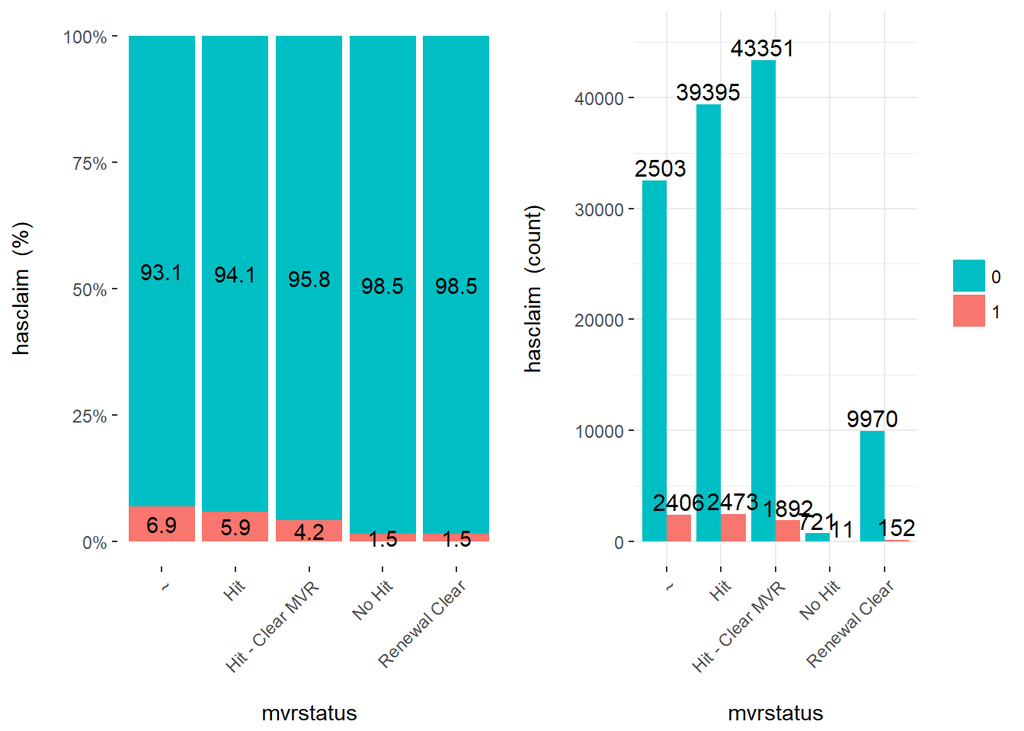

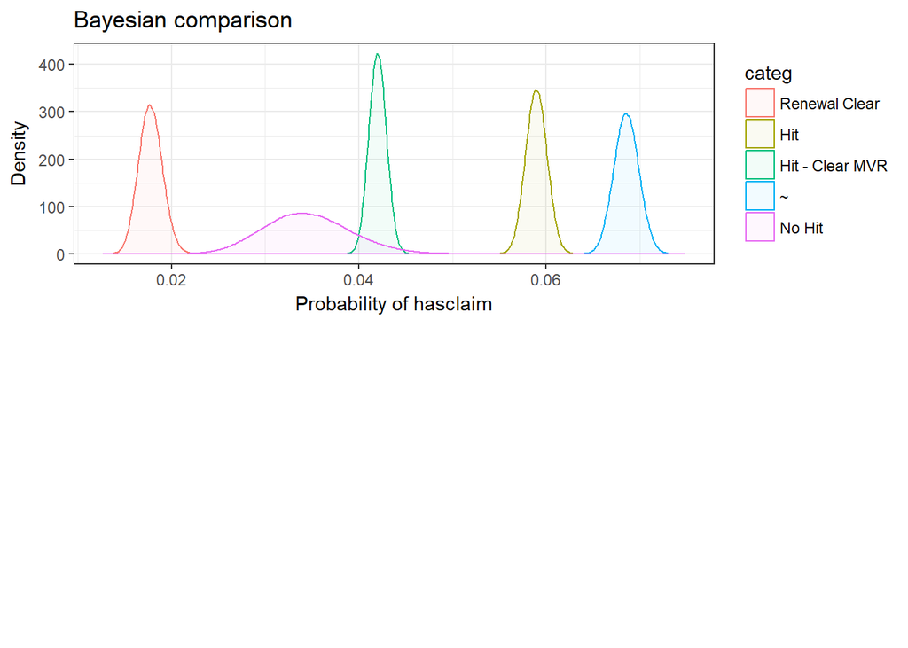

```r
plot_categorical('mvrstatus')
```

Unknown or missing info drivers have the highest claim probability and Renewal Clear the lowest.

GoodDriver Indicator

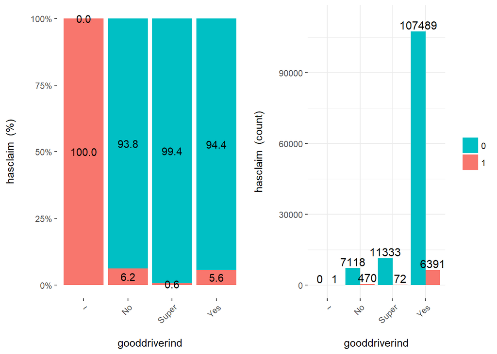

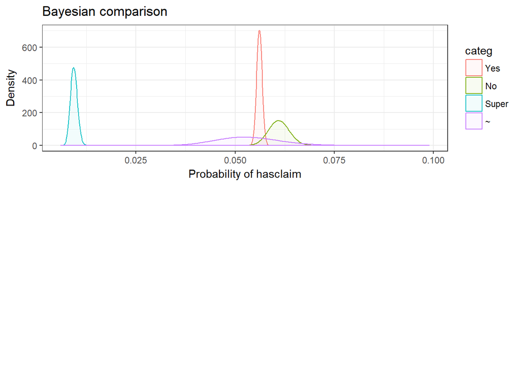

```r
plot_categorical('gooddriverind')
```

There is just one line with unknown (‘~’) value and it has claim. Let’s just ignore it. Not good drivers have the higest claim probability and percent

Accident Prevention Course Indicator

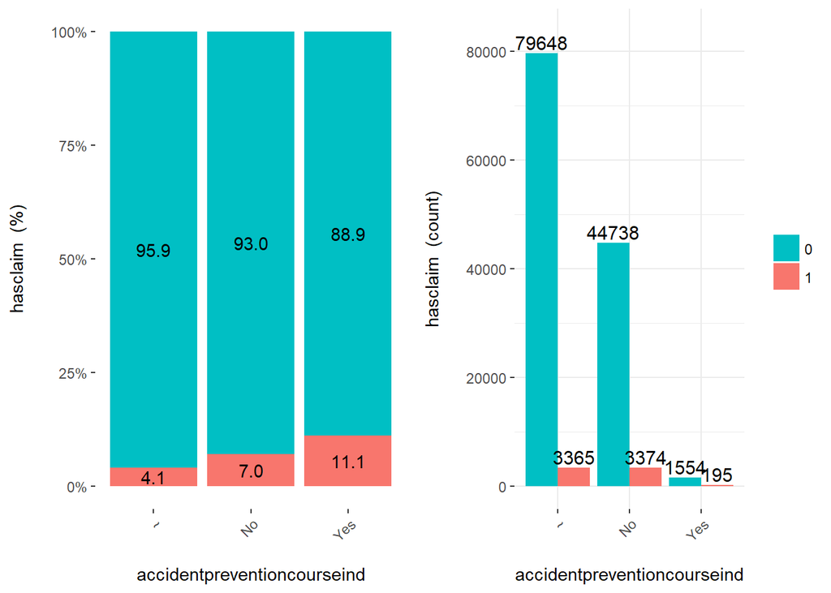

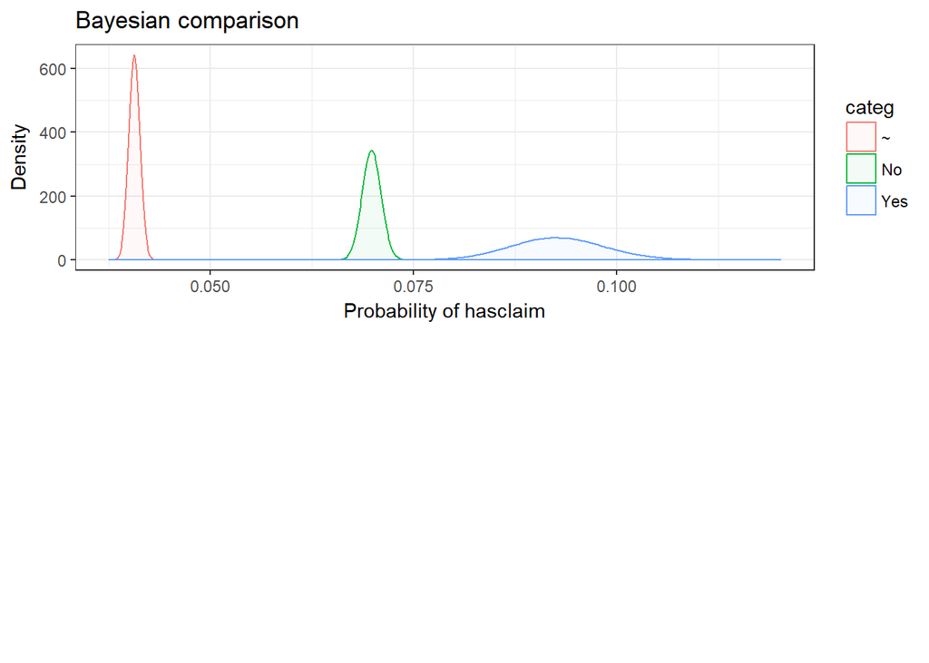

```r
plot_categorical('accidentpreventioncourseind')
```

Yes indicator has the highest claim probability. If the course was taken after a previous accident it makes sense.

Driver Training

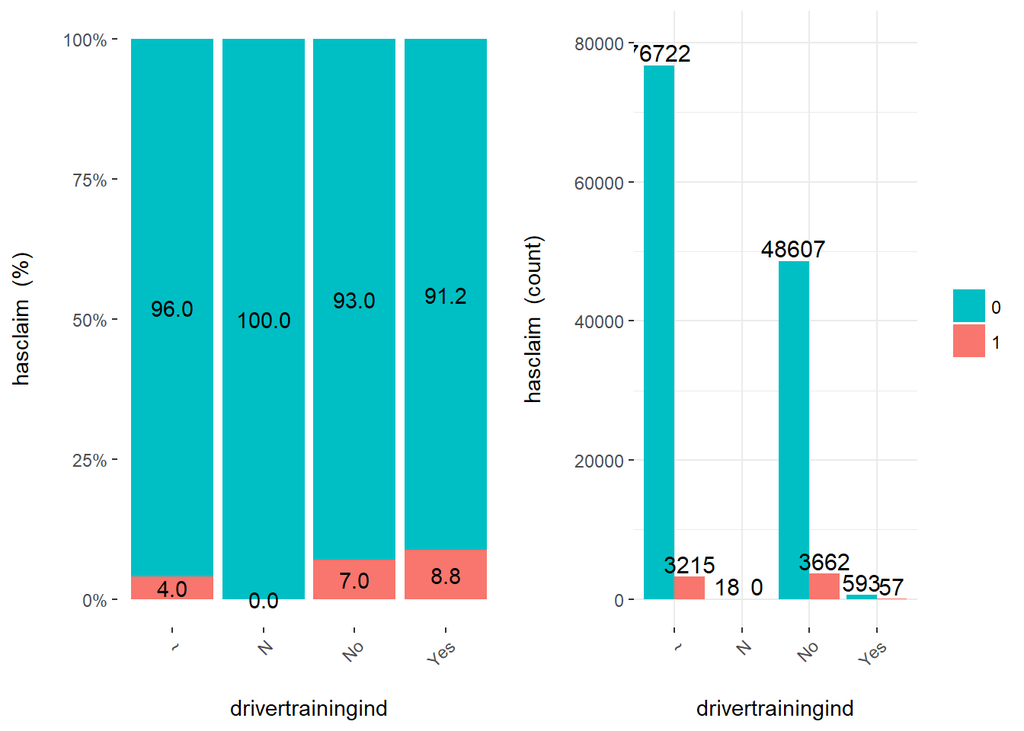

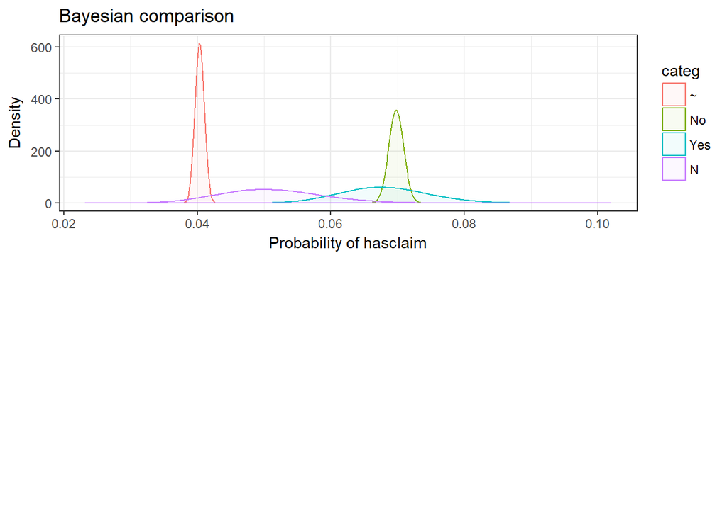

```r
plot_categorical('drivertrainingind')
```

Almost equal probability of a claim with or without Driver Training but percent of claims is a little bit higher for driver with training

Scholasticdiscountind

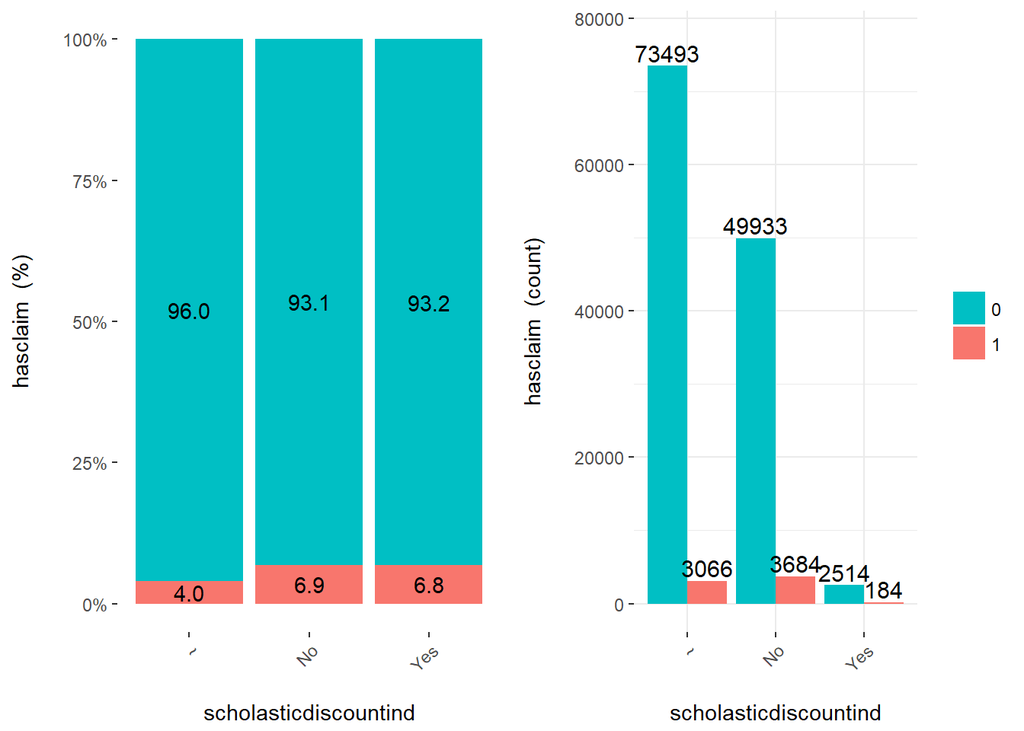

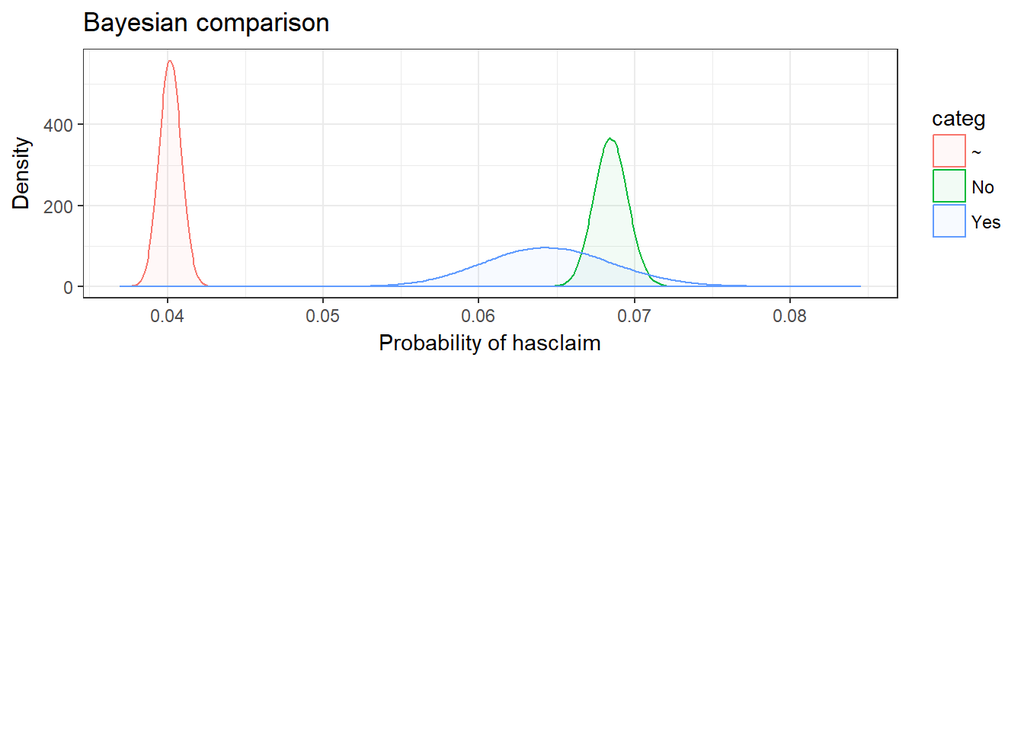

```r
plot_categorical('scholasticdiscountind')
```

Yes and No have approximately the same percent and probability of claims.

Relationship To Insured

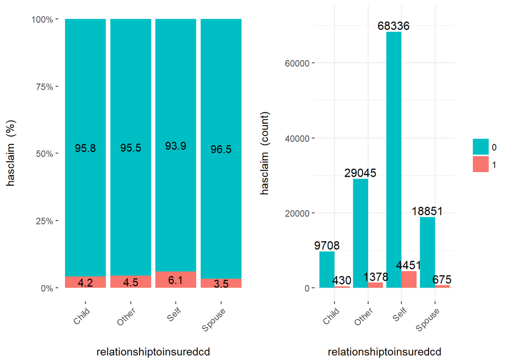

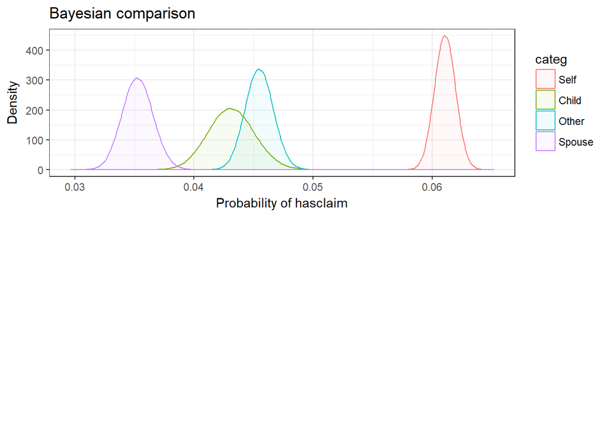

```r
plot_categorical('relationshiptoinsuredcd')
```

Marital Status

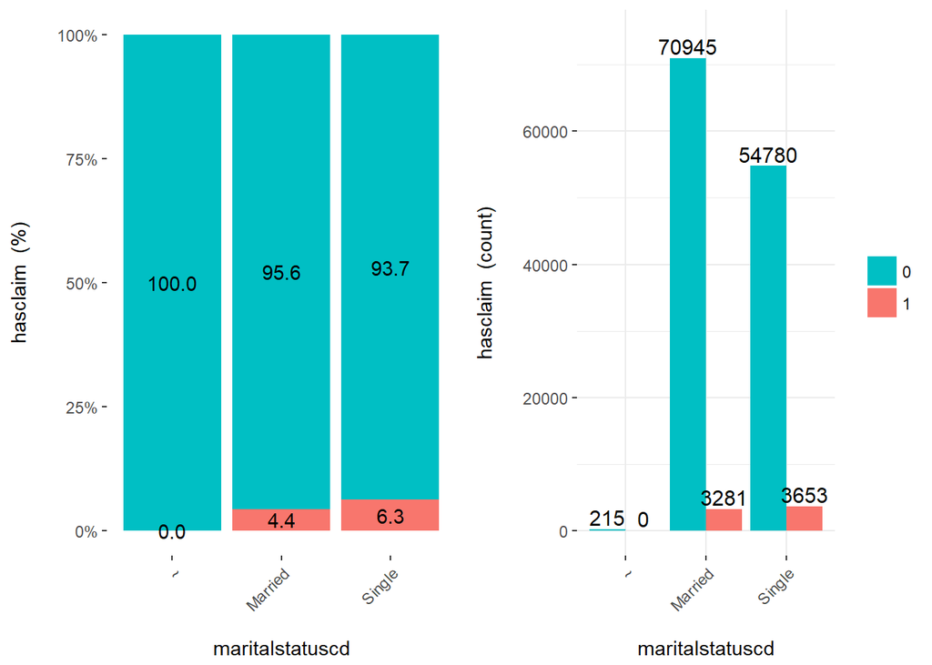

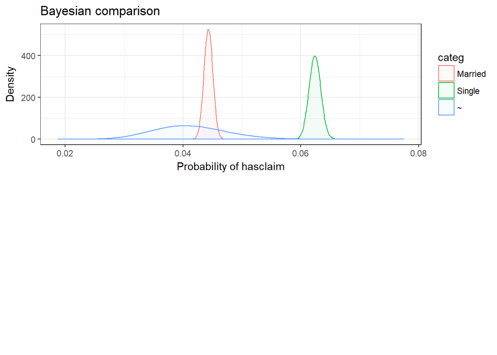

```r
plot_categorical('maritalstatuscd')
```

Carpoolind

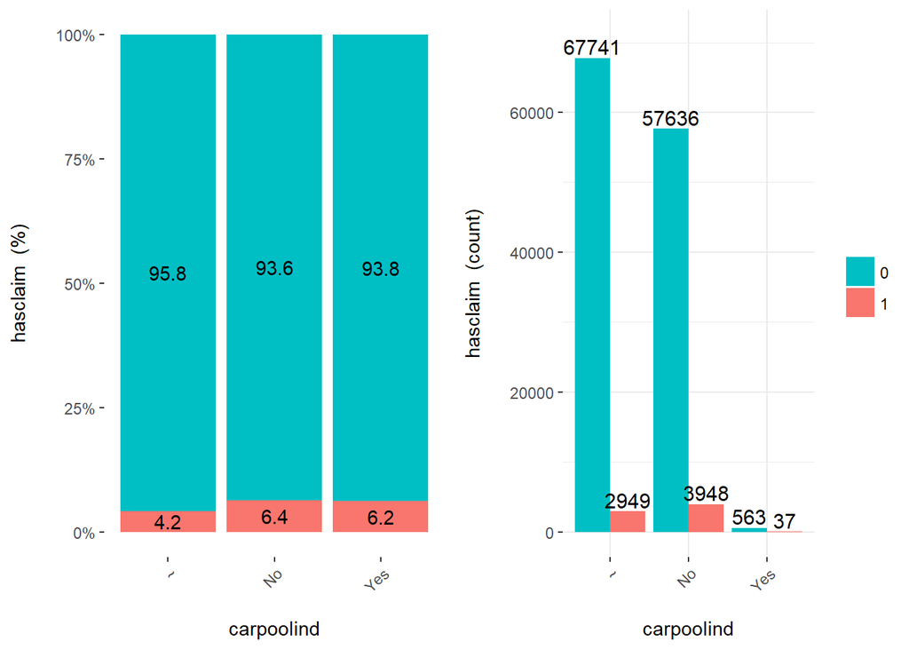

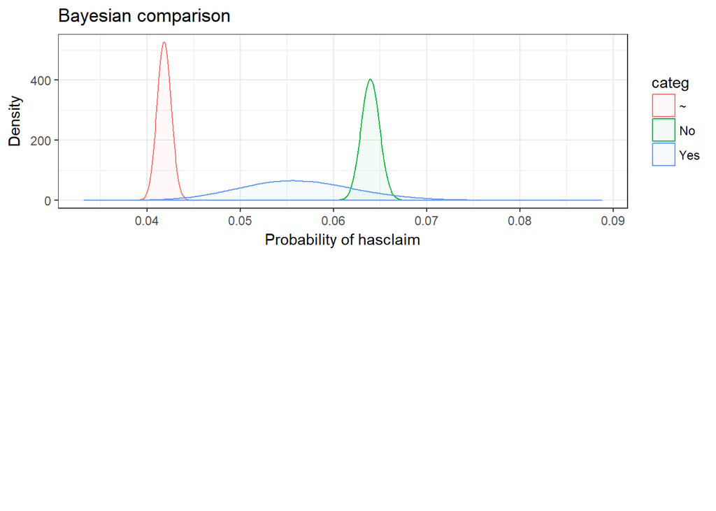

```r
plot_categorical('carpoolind')
```

Looks like bad drivers do not carpool. But the difference is very small.

High Cardinality Significant Features

In general, targeting encoding and then grouping resulting in less p-values and biggest CramerV values but there is not a big difference and reliability of the comparizon. (There are too many errors in calculation Chi-test).

```r
print_group_content <- function (col_name, suffix) {
  cat <- as.data.frame(categ_analysis(data=dataset,input=paste(col_name,suffix, sep=''), target=target))
    max_grp <- cat[which(cat$mean_target == max(cat$mean_target)), c(paste(col_name,suffix, sep=''))]
    min_grp <- cat[which(cat$mean_target == min(cat$mean_target)), c(paste(col_name,suffix, sep=''))]
    print("........................................................")
    print('Highest Target Mean levels (first 20 detail levels or all) in ')
    print(max_grp)
    print("........................................................")
    print(head(unique(dataset[which(dataset[[paste(col_name,suffix, sep='')]] == max_grp), ][col_name]),20))
    print("........................................................")
    print('Lowest Target Mean levels  (first 20 detail levels or all) in ')
    print(min_grp)
    print("........................................................")
    print(head(unique(dataset[which(dataset[[paste(col_name,suffix, sep='')]] == min_grp), ][col_name]),20))
}
```

DriverNumber and VehicleNumber

Of course, number 1 has highest claim likehood. All grouping methods think so.

```r
print_group_content('drivernumber','_trgbin')
```

```
## [1] "........................................................"
## [1] "Highest Target Mean levels (first 20 detail levels or all) in "
## [1] 5
## Levels: 1 2 3 4 5
## [1] "........................................................"
##   drivernumber
## 1            1
## [1] "........................................................"
## [1] "Lowest Target Mean levels  (first 20 detail levels or all) in "
## [1] 4
## Levels: 1 2 3 4 5
## [1] "........................................................"
##       drivernumber
## 473              9
## 933             10
## 1454             8
## 3009            15
## 17933           11
## 25725           12
## 27529           14
## 33854           13
## 35258           18
## 55596           19
## 60226           17
## 91486           16
```

```r
print_group_content('vehnumber','_trgbin')
```

```
## [1] "........................................................"
## [1] "Highest Target Mean levels (first 20 detail levels or all) in "
## [1] 5
## Levels: 1 2 3 4 5
## [1] "........................................................"
##   vehnumber
## 2         1
## [1] "........................................................"
## [1] "Lowest Target Mean levels  (first 20 detail levels or all) in "
## [1] 1
## Levels: 1 2 3 4 5
## [1] "........................................................"
##      vehnumber
## 37           9
## 2337        10
```

VehBodyTypecd

Vans have more claims. Is it because of its dimensions?

```r
print_group_content('vehbodytypecd','_trgbin')
```

```
## [1] "........................................................"
## [1] "Highest Target Mean levels (first 20 detail levels or all) in "
## [1] 5
## Levels: 1 2 3 4 5
## [1] "........................................................"
##    vehbodytypecd
## 24           Van
## [1] "........................................................"
## [1] "Lowest Target Mean levels  (first 20 detail levels or all) in "
## [1] 1
## Levels: 1 2 3 4 5
## [1] "........................................................"
##                       vehbodytypecd
## 34          Wagon - Two-Wheel Drive
## 52  Pickup Truck - Four-Wheel Drive
## 639                     Convertible
```

Model does not provide a lot of value in the claim prediction. It’s just interesting to take a look in grouping.

Clustring grouping just takes into account most popular models. Target encoding is more interseting. Please note how percent of claims changes fromgroup to group.

```r
print_group_content('external_model','_kmeans')
```

```
## [1] "........................................................"
## [1] "Highest Target Mean levels (first 20 detail levels or all) in "
## [1] "group_4"
## [1] "........................................................"
##       external_model
## 3              Civic
## 14566         Accord
## 53347          Camry
## [1] "........................................................"
## [1] "Lowest Target Mean levels  (first 20 detail levels or all) in "
## [1] "group_3"
## [1] "........................................................"
##     external_model
## 5          Stratus
## 6         Intrepid
```

[output cut: 18 more lines]

Target encoding

```r
print_group_content('external_model','_trgbin')
```

```
## [1] "........................................................"
## [1] "Highest Target Mean levels (first 20 detail levels or all) in "
## [1] 5
## Levels: 1 2 3 4 5
## [1] "........................................................"
##       external_model
## 14454  Sierra 2500HD
## 16641          Regal
## 47449            Fit
## 70612         RX 300
## [1] "........................................................"
## [1] "Lowest Target Mean levels  (first 20 detail levels or all) in "
## [1] 1
## Levels: 1 2 3 4 5
## [1] "........................................................"
##       external_model
## 6007           F-250
## 11999     S10 Pickup
## 13316   Yukon Denali
## 30501        Charger
## 30554       Windstar
## 68918        Integra
## 76706           Soul
```

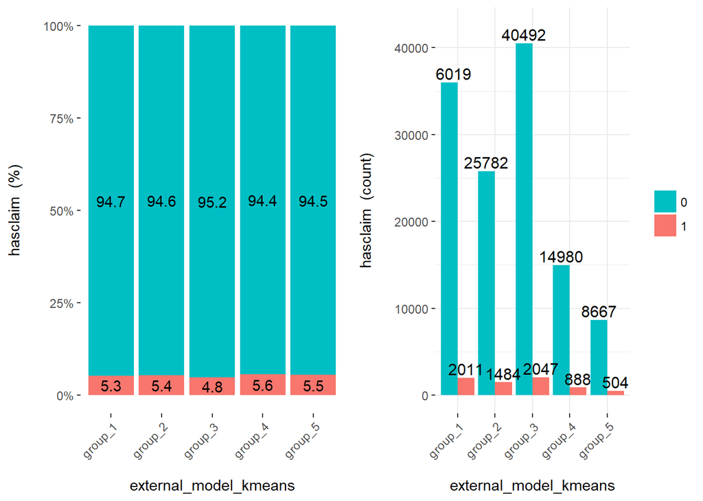

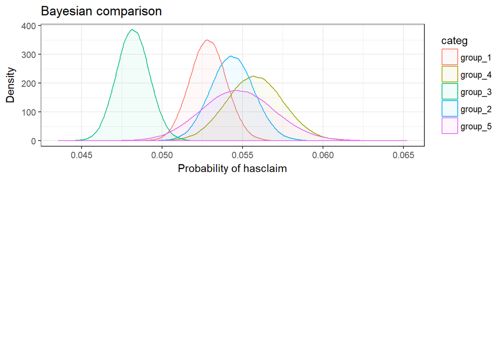

```r
plot_categorical('external_model_kmeans')
```

```r
print_group_content('model','_kmeans')
```

```
## [1] "........................................................"
## [1] "Highest Target Mean levels (first 20 detail levels or all) in "
## [1] "group_2"
## [1] "........................................................"
##                 model
## 3            CIVIC LX
## 14567       ACCORD EX
## 14568       ACCORD LX
## 28207 COROLLA CE/S/LE
## 53350      TYTA CAMRY
## [1] "........................................................"
## [1] "Lowest Target Mean levels  (first 20 detail levels or all) in "
## [1] "group_1"
## [1] "........................................................"
##                     model
```

[output cut: 20 more lines]

Target encoding:

```r
print_group_content('model','_trgbin')
```

```
## [1] "........................................................"
## [1] "Highest Target Mean levels (first 20 detail levels or all) in "
## [1] 5
## Levels: 1 2 3 4 5
## [1] "........................................................"
##                                model
## 47589 TACOMA PRERUNNER/PRERUNNER SR5
## [1] "........................................................"
## [1] "Lowest Target Mean levels  (first 20 detail levels or all) in "
## [1] 1
## Levels: 1 2 3 4 5
## [1] "........................................................"
##        model
## 12648 PICKUP
```

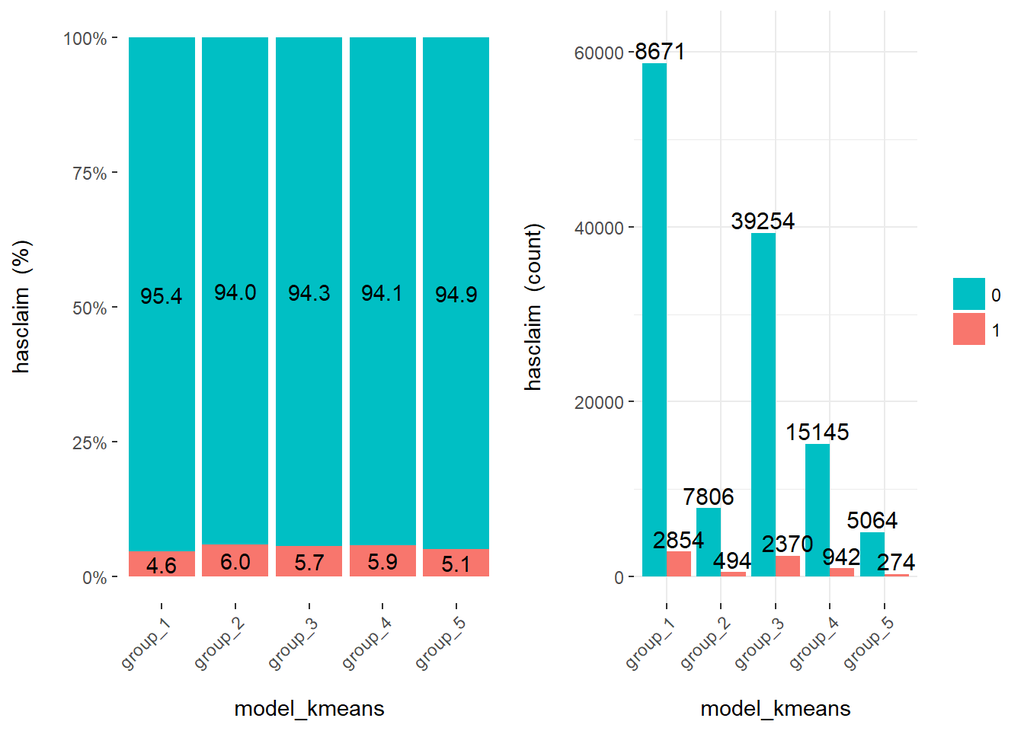

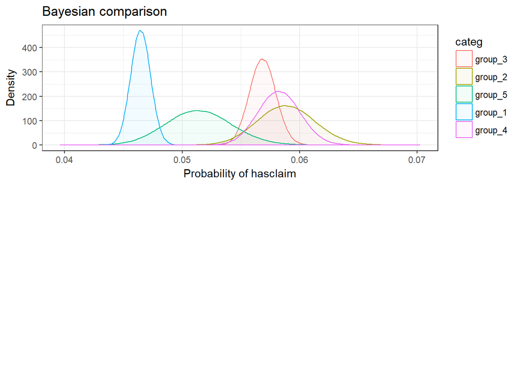

```r
plot_categorical('model_kmeans')
```

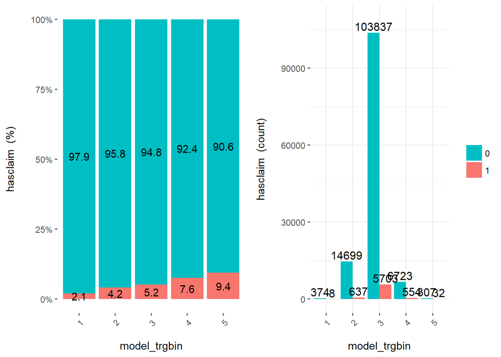

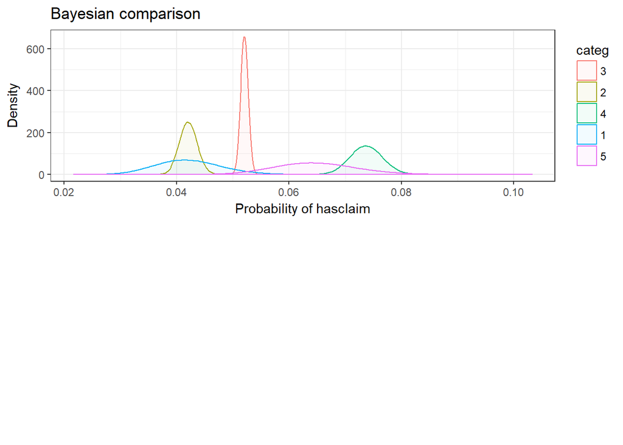

```r
plot_categorical('model_trgbin')
```

Acci_last_infractionage

Targeting encoding and clustering have different results. I feel the targeting encoding is more reliable.

```r
print_group_content('acci_last_infractionage','_trgbin')
```

```
## [1] "........................................................"
## [1] "Highest Target Mean levels (first 20 detail levels or all) in "
## [1] 5
## Levels: 1 2 3 5
## [1] "........................................................"
##     acci_last_infractionage
## 535                       4
## [1] "........................................................"
## [1] "Lowest Target Mean levels  (first 20 detail levels or all) in "
## [1] 1
## Levels: 1 2 3 5
## [1] "........................................................"
##        acci_last_infractionage
## 1                            0
## 3062                         6
## 4995                         9
## 6413                         5
## 7424                         8
## 61899                       -2
## 76367                        7
## 109607                      10
```

```r
print_group_content('acci_last_infractionage','_hclust')
```

```
## [1] "........................................................"
## [1] "Highest Target Mean levels (first 20 detail levels or all) in "
## [1] "group_1"
## [1] "........................................................"
##        acci_last_infractionage
## 3062                         6
## 4995                         9
## 6413                         5
## 7424                         8
## 61899                       -2
## 76367                        7
## 109607                      10
## [1] "........................................................"
## [1] "Lowest Target Mean levels  (first 20 detail levels or all) in "
## [1] "group_5"
## [1] "........................................................"
##   acci_last_infractionage
## 1                       0
```

```r
print_group_content('acci_last_infractionage','_kmeans')
```

```
## [1] "........................................................"
## [1] "Highest Target Mean levels (first 20 detail levels or all) in "
## [1] "group_1"
## [1] "........................................................"
##        acci_last_infractionage
## 3062                         6
## 4995                         9
## 6413                         5
## 7424                         8
## 61899                       -2
## 76367                        7
## 109607                      10
## [1] "........................................................"
## [1] "Lowest Target Mean levels  (first 20 detail levels or all) in "
## [1] "group_3"
## [1] "........................................................"
##   acci_last_infractionage
## 1                       0
```

Acci_last_convictionage

```r
print_group_content('acci_last_convictionage','_trgbin')
```

```
## [1] "........................................................"
## [1] "Highest Target Mean levels (first 20 detail levels or all) in "
## [1] 5
## Levels: 1 2 3 5
## [1] "........................................................"
##    acci_last_convictionage
## 87                       3
## [1] "........................................................"
## [1] "Lowest Target Mean levels  (first 20 detail levels or all) in "
## [1] 1
## Levels: 1 2 3 5
## [1] "........................................................"
##        acci_last_convictionage
## 1                            0
## 535                          4
## 3062                         6
## 4995                         9
## 6413                         5
## 7424                         8
## 76367                        7
## 109607                      10
```

Viol_last_infractionage

```r
print_group_content('viol_last_infractionage','_trgbin')
```

```
## [1] "........................................................"
## [1] "Highest Target Mean levels (first 20 detail levels or all) in "
## [1] 5
## Levels: 1 2 5
## [1] "........................................................"
##     viol_last_infractionage
## 341                       4
## [1] "........................................................"
## [1] "Lowest Target Mean levels  (first 20 detail levels or all) in "
## [1] 1
## Levels: 1 2 5
## [1] "........................................................"
##        viol_last_infractionage
## 1                            0
## 4                            7
## 72                           2
## 92                           1
## 6838                         8
## 9777                         6
## 11407                        5
## 15626                       12
## 24297                        9
## 24966                       20
## 29629                       18
## 31006                       15
## 42955                       21
## 60187                       -1
## 82946                       13
## 94108                       35
## 103984                      16
```

Viol_last_convictionage

```r
print_group_content('viol_last_convictionage','_trgbin')
```

```
## [1] "........................................................"
## [1] "Highest Target Mean levels (first 20 detail levels or all) in "
## [1] 5
## Levels: 1 2 5
## [1] "........................................................"
##     viol_last_convictionage
## 779                       4
## [1] "........................................................"
## [1] "Lowest Target Mean levels  (first 20 detail levels or all) in "
## [1] 1
## Levels: 1 2 5
## [1] "........................................................"
##        viol_last_convictionage
## 1                            0
## 4                            2
## 92                           1
## 9577                         7
## 14157                        5
## 24297                        9
## 32819                        6
## 107793                       8
## 130867                      -1
```

Interesting, the age of last accident and violation infraction and conviction are very close in grouping.

In general, I would try to combine acci and viol features in the further analysis.

Acci_pointschargedterm

```r
print_group_content('acci_pointschargedterm','_trgbin')
```

```
## [1] "........................................................"
## [1] "Highest Target Mean levels (first 20 detail levels or all) in "
## [1] 5
## Levels: 1 3 5
## [1] "........................................................"
##    acci_pointschargedterm
## 12                      1
## [1] "........................................................"
## [1] "Lowest Target Mean levels  (first 20 detail levels or all) in "
## [1] 1
## Levels: 1 3 5
## [1] "........................................................"
##        acci_pointschargedterm
## 1                           0
## 71                          3
## 1133                        4
## 14535                       5
## 39547                       8
## 55374                       6
## 100450                      7
```

Viol_pointschargedterm

```r
print_group_content('viol_pointschargedterm','_trgbin')
```

```
## [1] "........................................................"
## [1] "Highest Target Mean levels (first 20 detail levels or all) in "
## [1] 5
## Levels: 1 2 3 5
## [1] "........................................................"
##    viol_pointschargedterm
## 68                      1
## [1] "........................................................"
## [1] "Lowest Target Mean levels  (first 20 detail levels or all) in "
## [1] 3
## Levels: 1 2 3 5
## [1] "........................................................"
##       viol_pointschargedterm
## 2992                       4
## 3027                      13
## 3056                       3
## 8438                       5
## 14053                      6
## 28254                      8
```

```r
print_group_content('viol_pointschargedterm','_trgbin')
```

```
## [1] "........................................................"
## [1] "Highest Target Mean levels (first 20 detail levels or all) in "
## [1] 5
## Levels: 1 2 3 5
## [1] "........................................................"
##    viol_pointschargedterm
## 68                      1
## [1] "........................................................"
## [1] "Lowest Target Mean levels  (first 20 detail levels or all) in "
## [1] 3
## Levels: 1 2 3 5
## [1] "........................................................"
##       viol_pointschargedterm
## 2992                       4
## 3027                      13
## 3056                       3
## 8438                       5
## 14053                      6
## 28254                      8
```

Acci_driverpointsnumbercountterm

```r
print_group_content('acci_driverpointsnumbercountterm','_trgbin')
```

```
## [1] "........................................................"
## [1] "Highest Target Mean levels (first 20 detail levels or all) in "
## [1] 2
## Levels: 1 2 5
## [1] "........................................................"
##     acci_driverpointsnumbercountterm
## 542                                3
## [1] "........................................................"
## [1] "Lowest Target Mean levels  (first 20 detail levels or all) in "
## [1] 1
## Levels: 1 2 5
## [1] "........................................................"
##        acci_driverpointsnumbercountterm
## 1                                     0
## 1197                                  4
## 13900                                 5
## 118556                                6
```

Viol_driverpointsnumbercountterm

```r
print_group_content('viol_driverpointsnumbercountterm','_trgbin')
```

```
## [1] "........................................................"
## [1] "Highest Target Mean levels (first 20 detail levels or all) in "
## [1] 5
## Levels: 1 2 3 5
## [1] "........................................................"
##     viol_driverpointsnumbercountterm
## 528                                3
## [1] "........................................................"
## [1] "Lowest Target Mean levels  (first 20 detail levels or all) in "
## [1] 1
## Levels: 1 2 3 5
## [1] "........................................................"
##       viol_driverpointsnumbercountterm
## 1                                    0
## 1388                                 4
## 2643                                 5
## 3027                                11
## 5034                                 6
## 6519                                 7
## 21015                               13
## 27908                                8
## 42593                                9
## 52304                               16
## 68737                               17
## 94491                               14
```

Acci_infractioncdcountterm

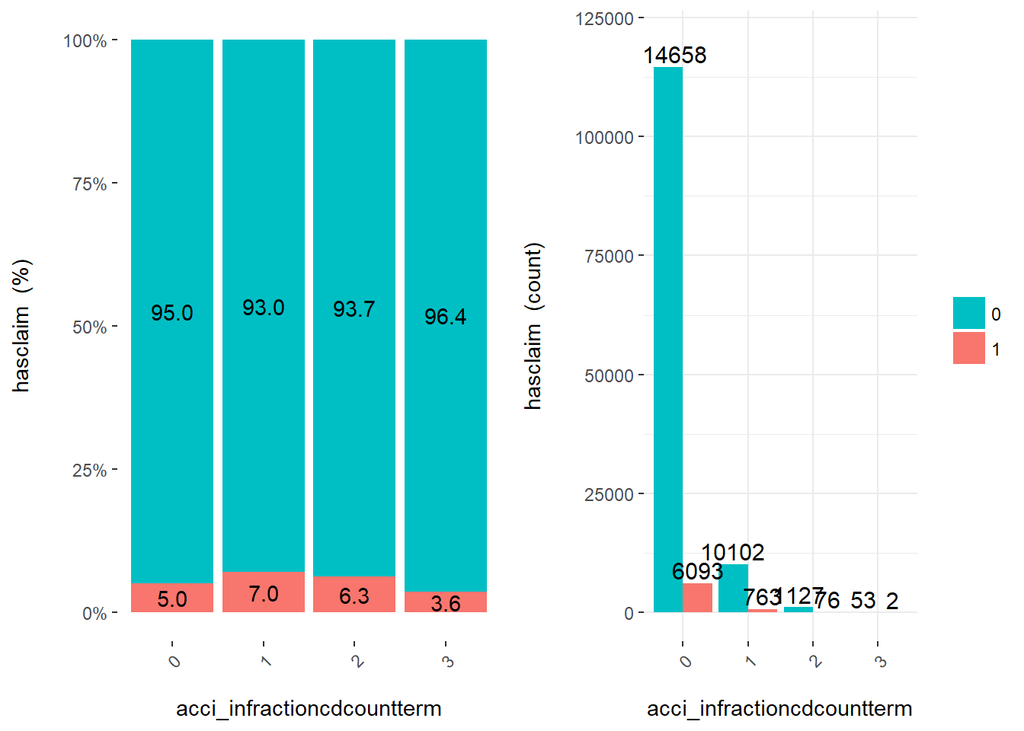

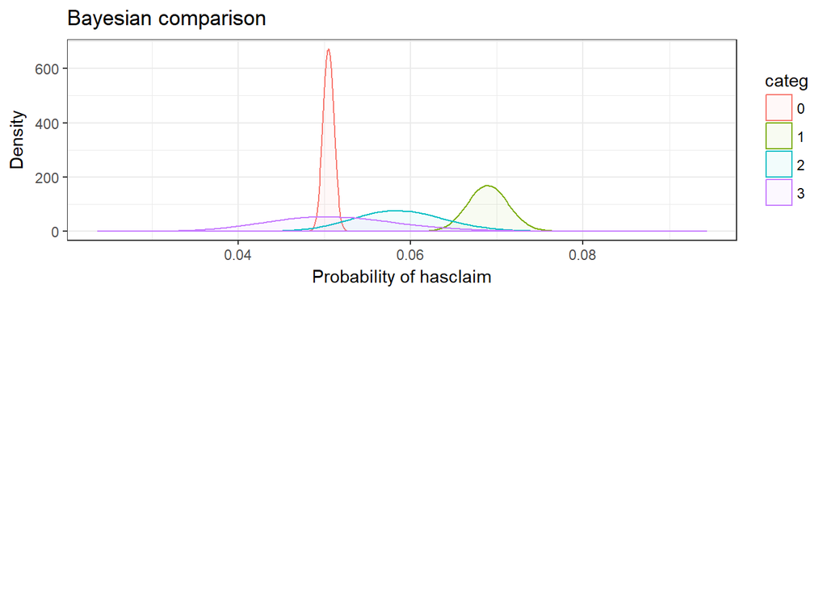

```r
plot_categorical('acci_infractioncdcountterm')
```

6. Continuous features analysis

Some features can be analyzed as categorical and as numerical

```r
categorical_numbers <- c(
 'vehnumber',
 'drivernumber',
 'viol_pointschargedterm',
 'acci_pointschargedterm',
 'viol_driverpointsnumbercountterm',
 'acci_driverpointsnumbercountterm',
 'viol_infractioncdcountterm',
 'acci_infractioncdcountterm',
 'viol_last_infractionage',
 'acci_last_infractionage',
 'viol_last_convictionage',
 'acci_last_convictionage',
 'external_engine',
 'enginesize',
 'enginehorsepower'
)

dataset[categorical_numbers] <- sapply(dataset[categorical_numbers], as.numeric)
features_to_explore <-c(continuous,categorical_numbers)
```

6.1 Continuous features analysis. The loop calculate mean per target value, runs Shapiro test to test normality (optinal because the further analysis do not depend on the feature normality) and Wilcox test to test dependence with the target.

```r
continuous_stats_names <- c()
continuous_stats_shapiro_pvalue <- c()
continuous_stats_m0 <- c()
continuous_stats_m1 <- c()
continuous_stats_wilcox_pvalue <- c()
```

Some general statistics

```r
p <- as.data.frame(profiling_num(dataset, print_results = F, digits = 2))
write.csv(file='results/profiling_numerical.csv', x=p)
```

Loop

```r
for (i in 1:length(features_to_explore)) {
  col_name <- features_to_explore[i]
  continuous_stats_names[i] <- col_name
  s <- shapiro.test(dataset[sample(nrow(dataset), 5000), col_name])
  continuous_stats_shapiro_pvalue[i] <- s$p.value
  HasClaim <- dataset[(dataset[[target]] == '1'),col_name]
  continuous_stats_m1[i] <- mean(HasClaim)

  NoClaim <- dataset[(dataset[[target]] == '0'),col_name]
  continuous_stats_m0[i] <- mean(NoClaim)

  w <- wilcox.test(HasClaim, NoClaim)
  continuous_stats_wilcox_pvalue[i] <- w$p.value

}
```

6.2 Finalizing our finding in a table

```r
continuous_features_stats <- data.frame(continuous_stats_names,continuous_stats_shapiro_pvalue,continuous_stats_m0,continuous_stats_m1,continuous_stats_wilcox_pvalue)
names(continuous_features_stats) <- c('Feature', 'ShapiroPvalue', 'Mean0','Mean1','WilcoxPvalue')
write.csv(file='results/continuous_features_stats.csv', x=continuous_features_stats)
```

6.3 Not Significant Continuous Features

```r
print(continuous_features_stats[which(continuous_features_stats$WilcoxPvalue >=0.05), ])
```

```
##                    Feature ShapiroPvalue Mean0 Mean1 WilcoxPvalue
## 2       external_length_in       3.5e-74   187   189        0.071
## 3        external_width_in       2.6e-82    71    71        0.995
## 8  estimatedannualdistance       1.8e-55  9383  9226        0.489
## 26         external_engine       3.4e-42    24    24        0.375
```

6.4 Significant Continuous Features

```r
print(continuous_features_stats[which(continuous_features_stats$WilcoxPvalue < 0.05), ])
```

```
##                             Feature ShapiroPvalue   Mean0   Mean1
## 1                        modelscore       1.7e-60 2.6e-01 2.6e-01
## 4                external_height_in       4.8e-68 6.1e+01 6.2e+01
## 5               external_vehicleage       9.1e-37 9.4e+00 8.5e+00
## 6                        vehicleage       2.8e-36 9.4e+00 8.5e+00
## 7                       ratingvalue       1.7e-44 1.1e+01 1.2e+01
## 9                   odometerreading       1.3e-70 6.6e+04 5.7e+04
## 10                daysperweekdriven       1.7e-71 2.4e+00 2.3e+00
## 11                        driverage       5.1e-22 5.0e+01 5.3e+01
## 12                   havelicenseage       2.2e-84 1.7e+01 1.7e+01
## 13                     mvrstatusage       2.6e-70 4.6e-01 5.7e-01
## 14                        vehnumber       2.9e-62 9.4e+00 8.1e+00
## 15                     drivernumber       8.8e-71 6.2e+00 4.9e+00
## 16           viol_pointschargedterm       2.2e-90 1.1e+00 1.1e+00
## 17           acci_pointschargedterm       3.0e-88 1.1e+00 1.1e+00
```

[output cut: 35 more lines]

6.2 Visualization functions

```r
plot_continuous <- function (col_name) {
  HasClaim <- dataset[[target]]
  p1 <- ggplot(dataset, aes(x = dataset[[col_name]], fill=HasClaim)) +
  geom_histogram(bins=100) +
  labs(x = col_name, y = 'Count', title = paste("Histogram of", col_name))

  p2 <- ggplot(dataset, aes(x = dataset[[col_name]], col=HasClaim)) +
  geom_density() +
  labs(x = col_name, y = 'Density', title = paste("Density of", col_name))

  p3 <- ggplot(dataset, aes(x=target, y=dataset[[col_name]], col=HasClaim)) +
  geom_boxplot() +
  theme(legend.position = "none") +
  labs(y = col_name, title = paste("Box Plot of", col_name, "with target"))

  vec <- dataset[[col_name]]
  y <- quantile(vec[!is.na(vec)], c(0.25, 0.75))
  x <- qnorm(c(0.25, 0.75))
  slope <- diff(y)/diff(x)
  int <- y[1L] - slope * x[1L]

  p4 <- ggplot(dataset, aes(sample = dataset[[col_name]], col='red')) +
  stat_qq() +
  geom_abline(slope = slope, intercept = int) +
  theme(legend.position = "none") +
  labs(y = col_name, title = paste("QQ Plot of", col_name))


  multiplot(p1,p2,p3,p4, cols=2)
}


plot_categorical_add <- function(col_name) {

  p1 = bayesian_plot(data=dataset, input=col_name, target=target)
  p2 = cross_plot(data=dataset, str_input=col_name, str_target=target)
  multiplot(p1,p2, cols=1)
}
```

Driver Age has most visible difference between Claim and No Claim dependency

Driver Age

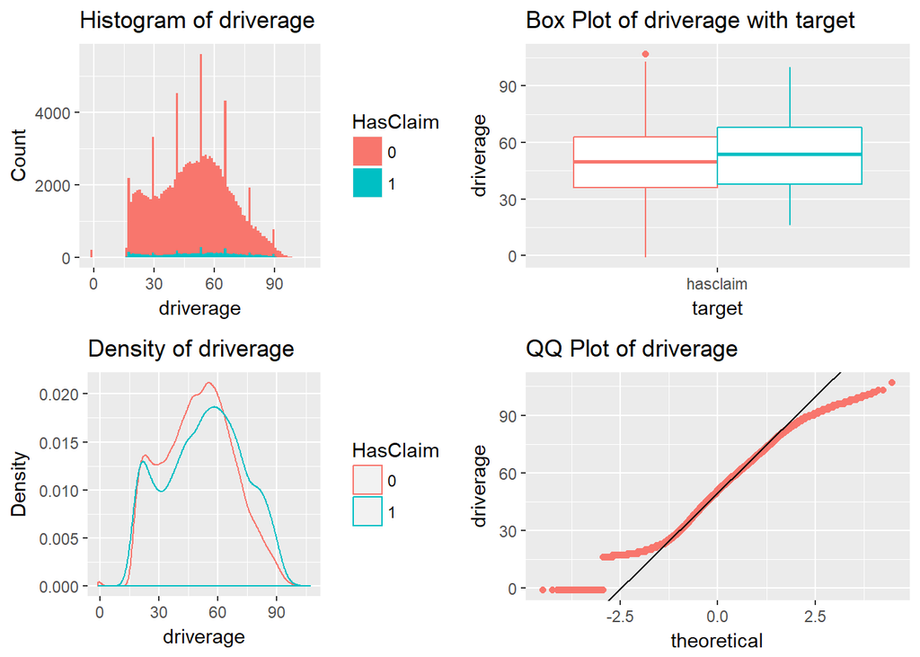

```r
plot_continuous('driverage')
```

The rest is just for information.

No one has normal distribution but because I am going to use a boosted tree model it is not a big deal. The features I analyzed as categorical (categorical_numbers) are indeed better to consider categorical. Excet, maybe, EngineSize and EngineHorsePower. But in both cases the dependence with claims is low.

Model Score

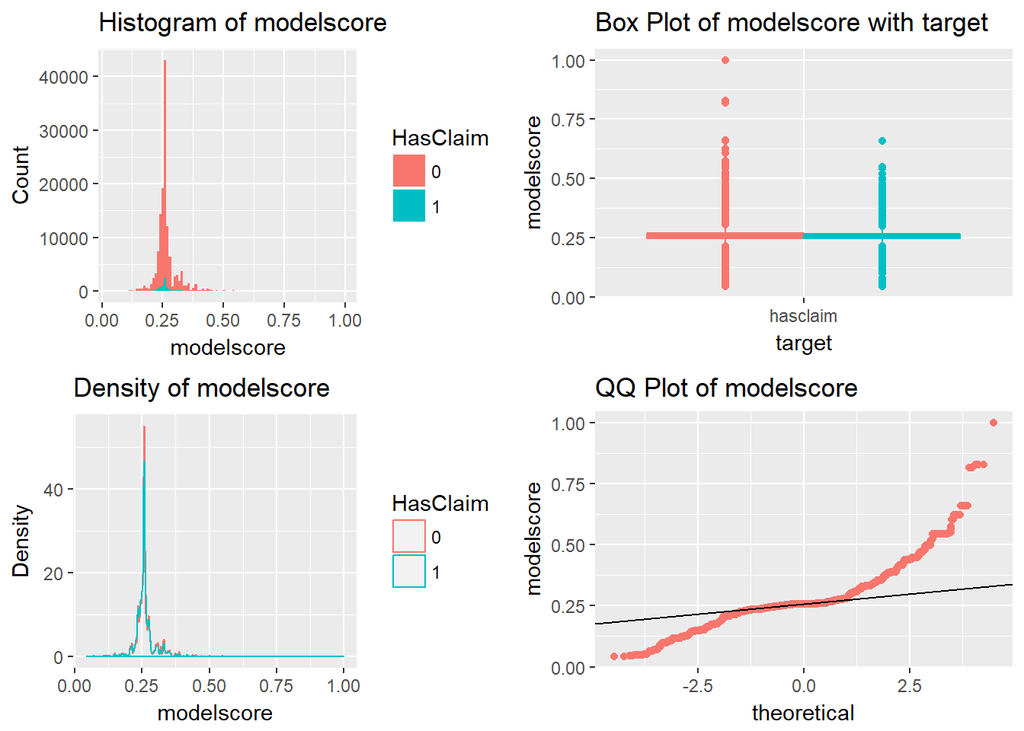

```r
plot_continuous('modelscore')
```

Rating value

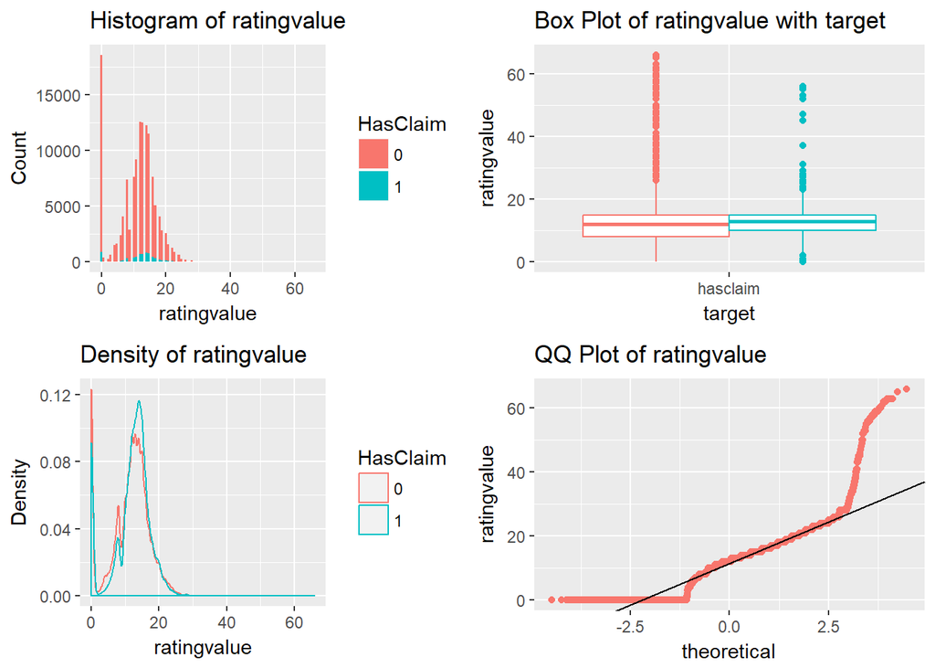

```r
plot_continuous('ratingvalue')
```

Vehicle Age

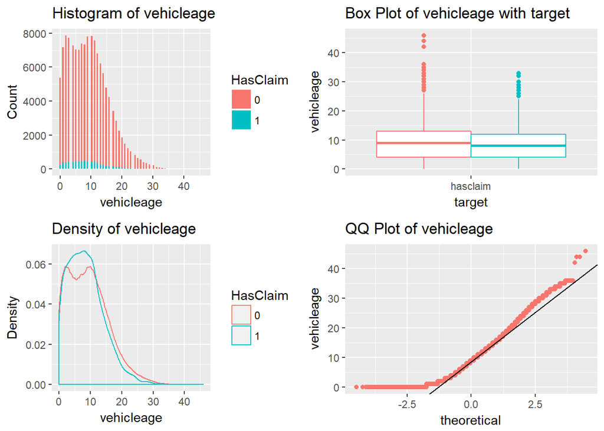

```r
plot_continuous('vehicleage')
```

Have License at Age

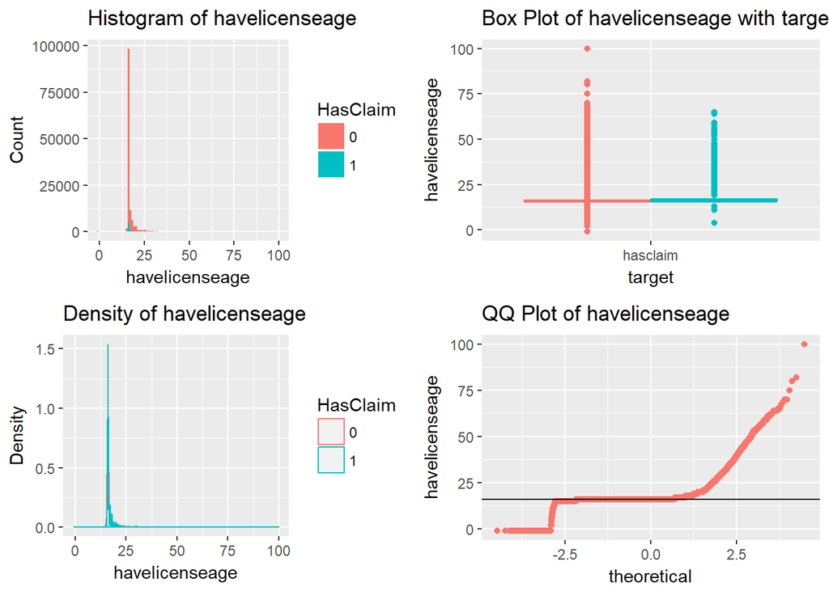

```r
plot_continuous('havelicenseage')
```

MVR Status Age